# Informe-ElPrecioDeLaDiscapacidad

Por otro lado, la comunidad con mayor proporción demográfica Murcia ya que está muy masificada y además es pequeña en extensión. Siguiendo los datos de la gráfica vemos que otras comunidades con altos valores demográficos serían Andalucia o Cataluña.

Para cerciorarnos de las conclusiones extraídas, vamos a comprobar cuántos **pueblos** presenta cada comunidad autónoma con un set de datos extraído del *Instituto Nacional de Estadística*.

```r
library(readxl)

Pueblos <- read_excel("DATA/Pueblos.xlsx")

View(Pueblos)

dim(Pueblos)
```

```
## [1] 18  2
```

```r
class(Pueblos)
```

```
## [1] "tbl_df"     "tbl"        "data.frame"
```

El set de datos es un tipo de data frame conocido como **tibble**.

También es conveniente transformar todos los nombres de la columna con “make.names” para cumplan las reglas sintácticas.

```r
Pueblos <- dplyr::rename(.data = Pueblos, Comunidad = `Comunidades Autónomas`)

Pueblos
```

```
## # A tibble: 18 x 2
##    Comunidad                   `Número de municipios`
##    <chr>                                        <dbl>
##  1 <NA>                                            NA
##  2 Andalucía                                      785
##  3 Aragón                                         731
##  4 Asturias, Principado de                         78
##  5 Balears, Illes                                  67
##  6 Canarias                                        88
##  7 Cantabria                                      102
##  8 Castilla y León                               2248
##  9 Castilla - La Mancha                           919
## 10 Cataluña                                       947
## 11 Comunitat Valenciana                           542
## 12 Extremadura                                    388
## 13 Galicia                                        313
## 14 Madrid, Comunidad de                           179
## 15 Murcia, Región de                               45
## 16 Navarra, Comunidad Foral de                    272
## 17 País Vasco                                     251
## 18 Rioja, La                                      174
```

```r
Pueblos <- Pueblos[-1,]

Pueblos
```

```
## # A tibble: 17 x 2
##    Comunidad                   `Número de municipios`
##    <chr>                                        <dbl>
##  1 Andalucía                                      785
##  2 Aragón                                         731
##  3 Asturias, Principado de                         78
##  4 Balears, Illes                                  67
##  5 Canarias                                        88
##  6 Cantabria                                      102
##  7 Castilla y León                               2248
##  8 Castilla - La Mancha                           919
##  9 Cataluña                                       947
## 10 Comunitat Valenciana                           542
## 11 Extremadura                                    388
## 12 Galicia                                        313
## 13 Madrid, Comunidad de                           179
## 14 Murcia, Región de                               45
## 15 Navarra, Comunidad Foral de                    272
## 16 País Vasco                                     251
## 17 Rioja, La                                      174
```

```r
make.names(Pueblos)
```

```
## [1] "c..Andalucía....Aragón....Asturias..Principado.de....Balears..Illes....Canarias....Cantabria....Castilla.y.León....Castilla...La.Mancha....Cataluña....Comunitat.Valenciana....Extremadura....Galicia....Madrid..Comunidad.de....Murcia..Región.de....Navarra..Comunidad.Foral.de....País.Vasco....R…
## [2] "c.785..731..78..67..88..102..2248..919..947..542..388..313..179..45..272..251..174."
```

```r
Pueblos[,2]
```

```
## # A tibble: 17 x 1
##    `Número de municipios`
##                     <dbl>
##  1                    785
##  2                    731
##  3                     78
##  4                     67
##  5                     88
##  6                    102
##  7                   2248
##  8                    919
##  9                    947
## 10                    542
## 11                    388
## 12                    313
## 13                    179
## 14                     45
## 15                    272
## 16                    251
## 17                    174
```

```r
typeof(Pueblos$`Número de municipios`)
```

```
## [1] "double"
```

```r
typeof(Pueblos$`Número de municipios`)
```

```
## [1] "double"
```

```r
summary(as.integer(Pueblos$`Número de municipios`), na.rm = TRUE)
```

```
##    Min. 1st Qu.  Median    Mean 3rd Qu.    Max.
##    45.0   102.0   272.0   478.2   731.0  2248.0
```

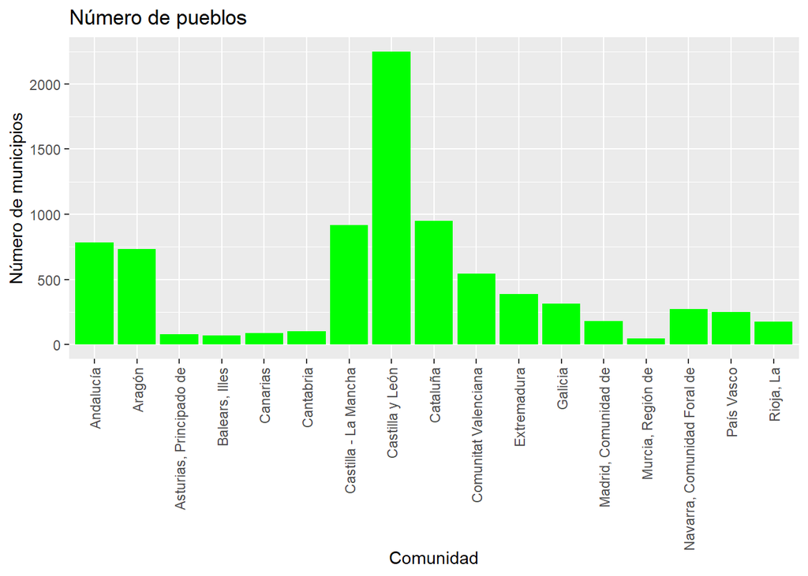

```r
ggplot(data = Pueblos, aes(x = `Comunidad`, y = `Número de municipios`)) +  geom_bar(stat="identity", position="stack", fill="green", show.legend = TRUE) + ggtitle("Número de pueblos")+ theme(axis.text.x = element_text(angle = 90, vjust = 0.5, hjust=1))
```

- **Conclusiones sobre la cantidad de pueblos**

Con los resultados obtenidos comprobamos que, efectivamente, **Castilla León** es la comunidad con más cantidad de pueblos con una amplia diferencia. Además, resulta sorprendente ver como otras comunidades que estaban muy pobladas tienen un número muy reducido de pueblos, tales como **Madrid** o **Murcia**. Andalucia y Cataluña vemos que tienen una amplio ámbito rural aunque también poseen muchas ciudades industrializadas, así que no vamos a fijarnos en sus características de forma significativa. De hecho las comunidades en las que mayor hincapié vamos a hacer debido a ser **ejemplos muy significativos** de los dos entornos que nos interesan son:

- *Zona rural*: **Castilla y León** y **Aragón**.
- *Zona urbana*: **Murcia** y **Madrid**.

#### Análisis de la contaminación

**1.** En primer lugar importamos los datos con “read_excel” porque tienen la extensión “.xsls”.

```r
library(readxl)

Contaminacion <- read_excel("DATA/Contaminacion.xlsx")

View(Contaminacion)
```

**2.** Vamos a comprobar algunas medidas estadísticas con la información recogidos en la columna “Contaminación”.

```r
dim(Contaminacion)
```

```
## [1] 19  2
```

```r
class(Contaminacion)
```

```
## [1] "tbl_df"     "tbl"        "data.frame"
```

El set de datos es un tipo de data frame conocido como **tibble**.

Además sabemos que el tibble contiene **19 filas y 2 columnas**, esto es así porque España se compone de 17 comunidades autónomas y 2 cuidades autónomas.

También es conveniente transformar todos los nombres de la columna con “make.names” para cumplan las reglas sintácticas.

```r
make.names(Contaminacion)
```

```
## [1] "c..Andalucía....Aragón....Asturias..Principado.de....Balears..Illes....Canarias....Cantabria....Castilla.y.León....Castilla...La.Mancha....Cataluña....Comunitat.Valenciana....Extremadura....Galicia....Madrid..Comunidad.de....Murcia..Región.de....Navarra..Comunidad.Foral.de....País.Vasco....R…
## [2] "c.10.1..5.9..15.5..19.7..9.2..5.6..4.3..1.8..10.6..6.9..4..2..18.5..9.4..9.3..10.4..6.7..6.2..21.1."
```

```r
Contaminacion$`Contaminación`
```

```
##  [1] 10.1  5.9 15.5 19.7  9.2  5.6  4.3  1.8 10.6  6.9  4.0  2.0 18.5  9.4  9.3
## [16] 10.4  6.7  6.2 21.1
```

```r
is.double(Contaminacion$`Contaminación`)
```

```
## [1] TRUE
```

- **La media y la mediana**

```r
mean(as.double(Contaminacion$`Contaminación`), na.rm = TRUE)
```

```
## [1] 9.326316
```

La media de los datos de contaminación es 9.32.

```r
median(as.double(Contaminacion$`Contaminación`), na.rm = TRUE)
```

```
## [1] 9.2
```

La mediana de los datos de contaminación es 9.2, al ser similar a la media sabemos que no habrá muchos valores extremos que me distorsionan la media.

- **Mínimo y máximo**

```r
Contaminacion$`Comunidad`[Contaminacion$`Contaminación` == min(as.double(Contaminacion$`Contaminación`), na.rm = TRUE)]
```

```
## [1] "Castilla - La Mancha"
```

La comunidad autónoma española con menos contaminación es **Castilla la Mancha**, con 1.8.

```r
Contaminacion$`Comunidad`[Contaminacion$`Contaminación` == max(as.double(Contaminacion$`Contaminación`), na.rm = TRUE)]
```

```
## [1] "Melilla"
```

La comunidad autónoma con más contaminación es **Melilla**, con 21.1.

- **Cálculo conjunto de varias medidas estadísticas**

```r
summary(as.double(Contaminacion$`Contaminación`), na.rm = TRUE)
```

```
##    Min. 1st Qu.  Median    Mean 3rd Qu.    Max.
##   1.800   5.750   9.200   9.326  10.500  21.100
```

- **Análisis de las comunidades más significativas**
  - **Castilla y León**: zona rural

```r
Contaminacion$`Contaminación`[Contaminacion$`Comunidad` == "Castilla y León"]
```

```
## [1] 4.3
```

La contaminación en Castilla y León es bastante baja comparado con la mayoría de las comunidades, es 4.3.

- **Aragón**: zona rural

```r
    Contaminacion$`Contaminación`[Contaminacion$`Comunidad` == "Aragón"]
```

```
## [1] 5.9
```

La contaminación en Aragón es más de tres puntos menor que la media, es 5.9.

- **Murcia**: zona urbana

```r
    Contaminacion$`Contaminación`[Contaminacion$`Comunidad` == "Murcia, Región de"]
```

```
## [1] 9.4
```

La contaminación en Murcia es algo mayor que la media, es 9.4.

- **Madrid**: zona urbana

```r
    Contaminacion$`Contaminación`[Contaminacion$`Comunidad` == "Madrid, Comunidad de"]
```

```
## [1] 18.5
```

La contaminación en Madrid es las más altas, duplica el valor de la media, es 18.5.

- **Representación gráfica de la información**

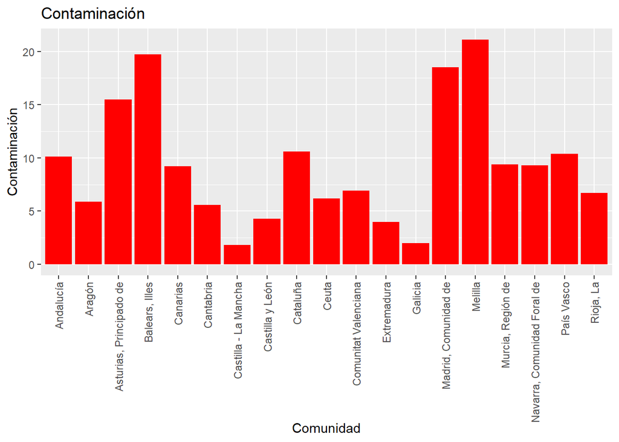

```r
ggplot(data = Contaminacion, aes(x = `Comunidad`, y = `Contaminación`)) +  geom_bar(stat="identity", position="stack", fill="red", show.legend = TRUE) + ggtitle("Contaminación") + theme(axis.text.x = element_text(angle = 90, vjust = 0.5, hjust=1))
```

- **Conclusiones**

Aunque no es una conclusión que se cumpla en todos los casos, vemos una clara relación entre un índice alto de contaminación y las ciudades. Históricamente siempre se han establecido las industrias más contaminantes en las zonas urbanas, así que en España podemos ver cómo aquellas comunidades que habíamos determinado como más urbanitas, y, consecuentemente, con más población, también presentan más contaminación.

Con nuestro set de datos, hemos visto que Melilla era la ciudad con más contaminación, pero debido a su situación especial no va a ser el dato más significativo para nosotras. El caso de Madrid sí que resulta esclarecedor ya que se compone principalmente de ciudades muy grandes y presenta mucha contaminación.

En el extremo opuesto, tenemos a Castilla y León que tenía el mayor número de pueblos y además, pesé a su gran extensión, también presenta índices muy bajos de contaminación. Castilla la Mancha es la comunidad con menos contaminación, y su caso es muy parecido al que acabo de mencionar. Con estos datos podemos determinar que **en los pueblos hay menos contaminación que en las ciudades**.

Sin embargo, ¿por qué hemos analizado la presencia de contaminación? Pues bien, la respuesta es clara, en este trabajo nos interesa describir algunas características que diferencian a los entornos que estamos comparando; y, en concreto, nos hemos centrado en parámetros que afectan a la salud humana, y, por tanto, a la aparición de ciertas discapacidades. Está comprobado por numerosas investigaciones (las cuales no vamos a incluir en este trabajo porque resultaría demasiado extenso) que **la contaminación es un factor agravante de disfunciones pulmonares, desórdenes cutáneos y problemas cardíacos**. De hecho se ha comprobado su relación con patologías muy incidentes que suponen la presencia de discapacidades, tales como: la diabetes la obesidad, la demencia senil, la infertilidad…

En conclusión, podemos determinar que **las condiciones de contaminación de las regiones rurales son mucho más favorables para la salud que las de las ciudades**. Esto también ocurre con muchos más parámetros que no analizaremos porque pretendemos quedarnos con ideas generales. Otros factores psicológicos que afectan al bienestar, y, por tanto, a la salud de las personas, serán analizados más adelante.

Para concluir con este análisis, voy a adjuntar algunas fuentes de información donde se puede profundizar sobre los efectos que tiene la contaminación en la salud humana.

- [Efectos de la contaminación atmosférica sobre la salud](https://scielo.isciii.es/scielo.php?script=sci_arttext&pid=S1135-57271999000200002/).
- [Medio ambiente y sus efectos sobre la salud](https://www.elsevier.es/es-revista-offarm-4-articulo-medio-ambiente-sus-efectos-sobre-13044458/).
- [Relación entre contaminación y salud](https://www.hospitallamoraleja.es/es/actualidad/73/relacion-entre-contaminacion-y-salud/).

#### Análisis de la satisfacción de las personas con el lugar donde viven

**1.** En primer lugar importamos los datos con “read_excel” porque tienen la extensión “.xsls”.

```r
library(readxl)

Satisfacción_con_el_entorno <- read_excel("DATA/Satisfaccion.xlsx")

View(Satisfacción_con_el_entorno)
```

**2.** Vamos a comprobar algunas medidas estadísticas con la información recogidos en la columna “Satisfacción”.

```r
dim(Satisfacción_con_el_entorno)
```

```
## [1] 19  2
```

```r
class(Satisfacción_con_el_entorno)
```

```
## [1] "tbl_df"     "tbl"        "data.frame"
```

El set de datos es un tipo de data frame conocido como **tibble**.

Además sabemos que el tibble contiene **19 filas y 2 columnas**, esto es así porque España se compone de 17 comunidades autónomas y 2 cuidades autónomas.

También es conveniente transformar todos los nombres de la columna con “make.names” para cumplan las reglas sintácticas.

```r
make.names(Satisfacción_con_el_entorno)
```

```
## [1] "c..Andalucía....Aragón....Asturias..Principado.de....Balears..Illes....Canarias....Cantabria....Castilla.y.León....Castilla.La.Mancha....Cataluña....Comunitat.Valenciana....Extremadura....Galicia....Madrid..Comunidad.de....Murcia..Región.de....Navarra..Comunidad.Foral.de....País.Vasco....Rio…
## [2] "c.7..7.6..7.7..7.6..7.1..7.6..7.4..7.4..7.2..7.2..7.3..6.6..7.1..7..7.8..7.5..7.4..6.3..6.8."
```

```r
Satisfacción_con_el_entorno$Satisfacción
```

```
##  [1] 7.0 7.6 7.7 7.6 7.1 7.6 7.4 7.4 7.2 7.2 7.3 6.6 7.1 7.0 7.8 7.5 7.4 6.3 6.8
```

```r
is.double(Satisfacción_con_el_entorno$Satisfacción)
```

```
## [1] TRUE
```

```r
typeof(Satisfacción_con_el_entorno$Satisfacción)
```

```
## [1] "double"
```

Los datos de la columna “Satisfacción” son de tipo “double”.

- **La media y la mediana**

```r
mean(as.double(Satisfacción_con_el_entorno$Satisfacción), na.rm = TRUE)
```

```
## [1] 7.242105
```

```r
median(as.double(Satisfacción_con_el_entorno$Satisfacción), na.rm = TRUE)
```

```
## [1] 7.3
```

- **Mínimo y máximo**

```r
Satisfacción_con_el_entorno$`Total`[Satisfacción_con_el_entorno$Satisfacción == min(as.double(Satisfacción_con_el_entorno$Satisfacción), na.rm = TRUE)]
```

```
## [1] "Ceuta"
```

La comunidad autónoma españolas con menor satisfacion es **Ceuta** con 6.3.

```r
Satisfacción_con_el_entorno$`Total`[Satisfacción_con_el_entorno$Satisfacción == max(as.double(Satisfacción_con_el_entorno$Satisfacción), na.rm = TRUE)]
```

```
## [1] "Navarra, Comunidad Foral de"
```

La comunidad autónoma más satisfecha es **Comunidad Foral de Navarra**, con 7.8.

- **Cálculo conjunto de varias medidas estadísticas (summary)**

```r
summary(as.double(Satisfacción_con_el_entorno$Satisfacción), na.rm = TRUE)
```

```
##    Min. 1st Qu.  Median    Mean 3rd Qu.    Max.
##   6.300   7.050   7.300   7.242   7.550   7.800
```

El mínimo es: 6.3

El máximo es: 7.8

El primer cuartil es: 7.05

El tercer cuartil es: 7.55

La media es: 7.242

- **Análisis de las comunidades más significativas**
  - **Castilla y León**: zona rural

```r
    Satisfacción_con_el_entorno$`Satisfacción`[Satisfacción_con_el_entorno$`Total` == "Castilla y León"]
```

```
## [1] 7.4
```

```
La satifacción con el entrono en Castilla y León son ligeramente superiores a la media, 7.4.
```

- **Aragón**: zona rural

```r
    Satisfacción_con_el_entorno$`Satisfacción`[Satisfacción_con_el_entorno$`Total` == "Aragón"]
```

```
## [1] 7.6
```

```
La satifacción con el entrono en Aragón son ligeramente superiores a la media, 7.6.
```

- **Murcia**: zona urbana

```r
    Satisfacción_con_el_entorno$`Satisfacción`[Satisfacción_con_el_entorno$`Total` == "Murcia, Región de"]
```

```
## [1] 7
```

```
La satifacción con el entrono en Región de Murcia, son ligeramente por debajo de la media, 7.
```

- **Madrid**: zona urbana

```r
    Satisfacción_con_el_entorno$`Satisfacción`[Satisfacción_con_el_entorno$`Total` == "Madrid, Comunidad de"]
```

```
## [1] 7.1
```

```
La satifacción con el entrono en Comunidad de Madrid son ligeramente por debajo de la media, 7.1.
```

- **Representación gráfica de la información demográfica**

Antes de comenzar a graficar hay que tener instalado el paquete básico *Tidyverse*.

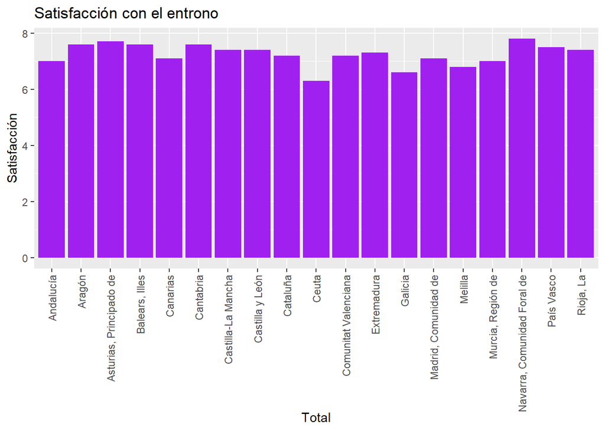

```r
library(tidyverse)
ggplot(data = Satisfacción_con_el_entorno, aes(x = `Total`, y = `Satisfacción`)) +  geom_bar(stat="identity", position="stack", fill="purple") + ggtitle("Satisfacción con el entrono") + theme(axis.text.x = element_text(angle = 90, vjust = 0.5, hjust=1))
```

- **Conclusiones sobre de la satisfacción con el entorno según la comunidad**

Basándonos en los datos obtuvimos mediante diversas operaciones sobre el set llamado Satisfacción del entorno en la vida, en este caso. Podemos afirmar que la comunidad más satisfecha es la Comunidad Foral de Navarra. Lo cual puede ser consecuencia de diversos factores, como los recursos, la economía, el clima, la sociedad… de dicha comunidad autónoma.

Por otro lado, la comunidad menos satisfecha con su entorno es Ceuta. La cual, puede deberse como en el caso anterior a diversos factores, pero también cabe a destacar que se trata de una de las ciudades autónomas más pequeñas del país.

Cuando nos hemos fijado en las comunidades más significativas o destacables, aunque no se vea una constante clara en sus cifras de satisfacción, si que hemos observado que siempre son cifras bastante cercanas al valor medio de todas las comunidades.

Finalmente, en el gráfico creado con todos los datos, se aprecia muy bien que en general la satisfacción no es muy dispar a la media. Por ello, podemos afirmar que ninguna comunidad o ciudad autónoma destaca por valores demasiado disparatados o diferenciados al resto. Con lo que podemos concluir que la satisfacción respecto del entorno en todo el país en general es bastante similar.

#### Análisis de la proporción de individuos discapacitados por comunidad autónoma

**1.** En primer lugar importamos los datos con “read_excel” porque tienen la extensión “.xsls”.

```r
library(readxl)

Discapacitados <- read_excel("DATA/Proporcion discapacitados.xlsx")

View(Discapacitados)
```

**2.** Vamos a comprobar algunas medidas estadísticas con la información recogidos en la columna “Personas con discapacidad”.

```r
dim(Discapacitados)
```

```
## [1] 19  2
```

```r
class(Discapacitados)
```

```
## [1] "tbl_df"     "tbl"        "data.frame"
```

El set de datos es un tipo de data frame conocido como **tibble**.

Además sabemos que el tibble contiene **19 filas y 2 columnas**, esto es así porque España se compone de 17 comunidades autónomas y 2 cuidades autónomas.

También es conveniente transformar todos los nombres de la columna con “make.names” para cumplan las reglas sintácticas.

```r
make.names(Discapacitados)
```

```
## [1] "c..Andalucía....Aragón....Asturias..Principado.de....Balears..Illes....Canarias....Cantabria....Castilla.y.León....Castilla...La.Mancha....Cataluña....Comunitat.Valenciana....Extremadura....Galicia....Madrid..Comunidad.de....Murcia..Región.de....Navarra..Comunidad.Foral.de....País.Vasco....R…
## [2] "c.16.72..19.77..12.6..19.1..12.86..17.55..16.01..13.72..16.89..16.23..17.67..17.24..17.58..13.65..19.59..13.59..17.22..17.16..16.18."
```

```r
Discapacitados$`Personas con discapacidad`
```

```
##  [1] 16.72 19.77 12.60 19.10 12.86 17.55 16.01 13.72 16.89 16.23 17.67 17.24
## [13] 17.58 13.65 19.59 13.59 17.22 17.16 16.18
```

```r
is.double(Discapacitados$`Personas con discapacidad`)
```

```
## [1] TRUE
```

```r
typeof(Discapacitados$`Personas con discapacidad`)
```

```
## [1] "double"
```

Los datos de la columna “Personas con discapacidad” son de tipo “double”, así que no necesitaremos transformarlos para utilizar las funciones estadísticas.

- **La media y la mediana**

```r
mean(Discapacitados$`Personas con discapacidad`, na.rm = TRUE)
```

```
## [1] 16.38579
```

La media de los datos sobre individuos discapacitados es 16.38579.

```r
median(Discapacitados$`Personas con discapacidad`, na.rm = TRUE)
```

```
## [1] 16.89
```

La mediana de los datos sobre individuos discapacitados es 16.89, al ser similar a la media podemos intuir que no habrá datos muy extremos que distorsionan la media.

- **Mínimo y máximo**

```r
Discapacitados$`Comunidades`[Discapacitados$`Personas con discapacidad` == min(Discapacitados$`Personas con discapacidad`, na.rm = TRUE)]
```

```
## [1] "Asturias, Principado de"
```

La comunidad autónoma española con menor dato demográfico es **Asturias**, con 12.60.

```r
Discapacitados$`Comunidades`[Discapacitados$`Personas con discapacidad` == max(Discapacitados$`Personas con discapacidad`, na.rm = TRUE)]
```

```
## [1] "Aragón"
```

La comunidad autónoma con mayor dato demográfico es **Aragón**, con 19.77.

- **Cálculo conjunto de varias medidas estadísticas (summary)**

```r
summary(Discapacitados$`Personas con discapacidad`, na.rm = TRUE)
```

```
##    Min. 1st Qu.  Median    Mean 3rd Qu.    Max.
##   12.60   14.87   16.89   16.39   17.57   19.77
```

El mínimo es: 12.60

El máximo es: 19.77

El primer cuartil es: 14.87

El tercer cuartil es: 17.57

La media es: 16.39

- **Análisis de las comunidades más significativas**
  - **Castilla y León**: zona rural

```r
Discapacitados$`Personas con discapacidad`[Discapacitados$`Comunidades`== "Castilla y León"]
```

```
## [1] 16.01
```

[output not shown]

- **Aragón**: zona rural

```r
Discapacitados$`Personas con discapacidad`[Discapacitados$`Comunidades`== "Aragón"]
```

```
## [1] 19.77
```

[output not shown]

- **Murcia**: zona urbana

```r
Discapacitados$`Personas con discapacidad`[Discapacitados$`Comunidades`== "Murcia, Región de"]
```

```
## [1] 13.65
```

[output not shown]

- **Madrid**: zona urbana

```r
Discapacitados$`Personas con discapacidad`[Discapacitados$`Comunidades`== "Madrid, Comunidad de"]
```

```
## [1] 17.58
```

[output not shown]

- **Representación gráfica de la información sobre la cantidad de discapacitados**

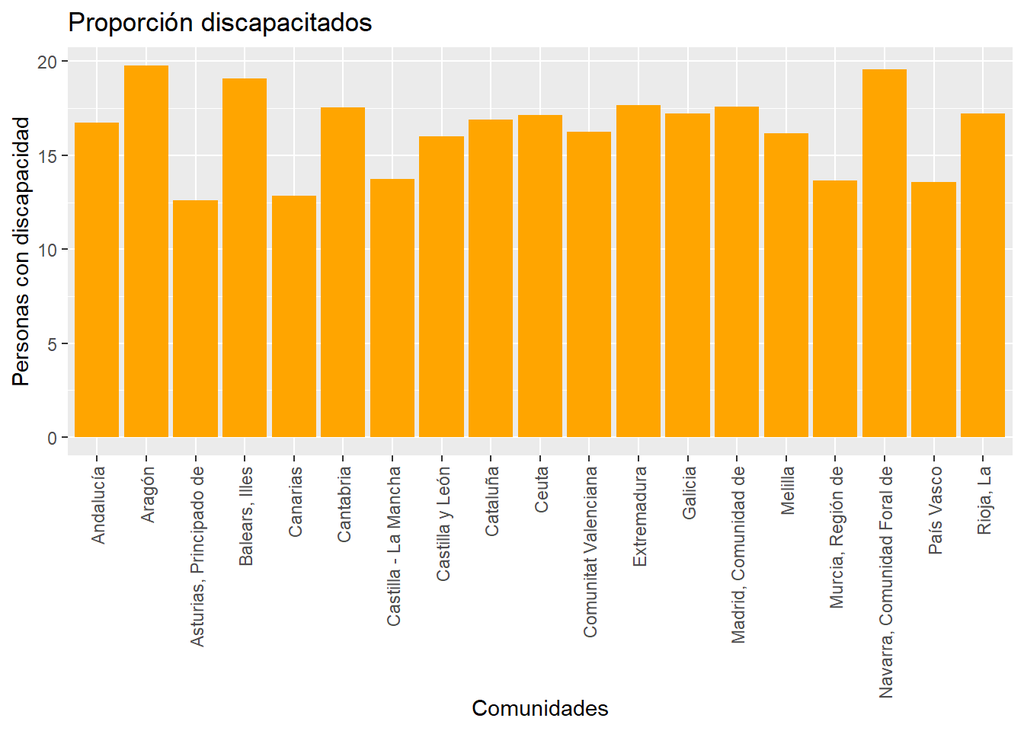

```r
library(tidyverse)
ggplot(data = Discapacitados, aes(x = `Comunidades`, y = `Personas con discapacidad`)) +  geom_bar(stat="identity", position="stack", fill="orange") + ggtitle("Proporción discapacitados") + theme(axis.text.x = element_text(angle = 90, vjust = 0.5, hjust=1))
```

- **Conclusiones sobre la información demográfica**

Con estos datos analizados vamos a intentar responder a la siguiente cuestión: ¿Existe mayor probabilidad de que aparezca discapacidades en ciudades que en pueblos?

Como podemos comprobar con la información estadística obtenida y el gráfico de barras representado, la comunidades con mayor proporción de personas discapacitadas es Aragón, mientras que la que menos discapacitados presenta es Asturias.

Sin embargo nosotros vamos a centrarnos en aquellas comunidades que habíamos determinado como significativas del ambiente rural y del ambiente urbano. Por un lado, como ambiente rural, tenemos a Castilla y León y Aragón que no tienen números especialmente bajos de discapacitados; de hecho, Aragón es la comunidad con mayor índice de discapacitados. Por otro lado, como ambiente urbano, tenemos representando a Murcia que tiene una proporción de discapacitados por debajo de la media, y a Madrid que tiene un índice de discapacidad algo superior a la media, pero no de los tres más altos.

Esto refleja que **no hay diferencias nada significativas entre la probabilidad de que aparezcan discapacidades en los pueblos o en las ciudades**. Es decir, características del entorno, como la contaminación o la densidad demográfica, no interfieren de forma transcendetal en el conjunto global de las discapacidades. Podemos intuir que esto se debe a que la mayor parte de las discapacidades tienen una implicación genética o se deben a accidentes casuales. Por si os resulta interesante vamos a adjuntar las direcciones de fuentes de información donde se analizan las **principales causas de discapacidad**:

- [Principales causas de discapacidad y muerte según la OMS](https://www.who.int/es/news/item/09-12-2020-who-reveals-leading-causes-of-death-and-disability-worldwide-2000-2019/).
- [Discapacidad, Autonomía personal y situaciones de Dependencia según la INE](https://www.ine.es/revistas/cifraine/1009.pdf/).

Como estamos hablando del conjunto genérico de las discapacidades y no de una tipología concreta concluimos diciendo que no hay una mayor tendencia de que aparezcan discapacidades en ciudades. Si tratasemos patologías donde es muy influyente el ambiente puede que sí hubiese relación entre ambos aspectos, sin embargo, esto se incluirá como materia del trabajo.

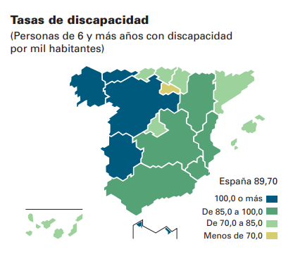

Dicho esto, la pregunta que ahora nos concierne es: ¿existe algún tipo de relación entre el progreso de una discapacidad y en entorno en el que habita el individuo discapacitado? O sea, ¿dónde evolucionan más favorablemente las discapacidades, en las ciudades o en los pueblos?

### 2. Análisis de las discapacidades

Con el fin de caracterizar cómo son las discapacidades en nuestro país, antes de responder a la anterior pregunta planteada, vamos a tratar ciertos parámetros generales de las discapacidades. No van a ser datos muy influyentes para nuestro objetivo final pero resultan interesantes al tratar este tema. En concreto, vamos a hablar del sexo, la edad, el grado de discapacidad y la economía de la discapacidad. A continuación incluímos el artículo de una revista de la INE donde se resume toda esta información de forma muy ilustrativa.

- [Panorámica de la discapacidad en España según la INE](https://www.ine.es/revistas/cifraine/1009.pdf/).

*También queremos aclarar que a partir de ahora vamos a simplificar el análisis estadístico de los sets de datos, sobre todo recurriremos al comando “summary”, para reducir el tamaño del trabajo.*

#### ¿Existe alguna relación entre el sexo y las discapacidades?

**1.** En primer lugar importamos los datos con “read_excel” porque tienen la extensión “.xsls”.

```r
library(readxl)

DiscSexo <- read_excel("DATA/Discapacidad por sexo.xlsx")

View(DiscSexo)
```

**2.** Vamos a comprobar algunas medidas estadísticas con la información recogidos en la columnas “Varones” y “Mujeres” por separado.

```r
dim(DiscSexo)
```

```
## [1] 19  3
```

```r
class(DiscSexo)
```

```
## [1] "tbl_df"     "tbl"        "data.frame"
```

El set de datos es un tipo de data frame conocido como **tibble**.

Además sabemos que el tibble contiene **19 filas y 3 columnas**, esto es así porque España se compone de 17 comunidades autónomas y 2 cuidades autónomas.

También es conveniente transformar todos los nombres de la columna con “make.names” para cumplan las reglas sintácticas.

```r
make.names(DiscSexo)
```

```
## [1] "c..Andalucía....Aragón....Asturias..Principado.de....Balears..Illes....Canarias....Cantabria....Castilla.y.León....Castilla...La.Mancha....Cataluña....Comunitat.Valenciana....Extremadura....Galicia....Madrid..Comunidad.de....Murcia..Región.de....Navarra..Comunidad.Foral.de....País.Vasco....R…
## [2] "c.1511.3..275.2..44.3..36.9..26.3..60..14.3..103.3..71.5..203.2..193.2..42..112..177.3..53.8..17.1..68.2..6.7..3.3."
## [3] "c.2276.2..440.9..67.3..67.7..42.5..75.8..23.2..152.6..111.4..308.5..259.5..69..181..257.6..73.7..24.5..101.2..11.2..4.1."
```

```r
DiscSexo$`Varones`
```

```
##  [1] 1511.3  275.2   44.3   36.9   26.3   60.0   14.3  103.3   71.5  203.2
## [11]  193.2   42.0  112.0  177.3   53.8   17.1   68.2    6.7    3.3
```

```r
DiscSexo$`Mujeres`
```

```
##  [1] 2276.2  440.9   67.3   67.7   42.5   75.8   23.2  152.6  111.4  308.5
## [11]  259.5   69.0  181.0  257.6   73.7   24.5  101.2   11.2    4.1
```

```r
is.double(DiscSexo$`Varones`)
```

```
## [1] TRUE
```

```r
typeof(DiscSexo$`Varones`)
```

```
## [1] "double"
```

Los datos de la primera y la segunda columna son de tipo “double”, así que no necesitaremos transformarlos para utilizar las funciones estadísticas.

- **La media y la mediana**

```r
mean(DiscSexo$`Varones`, na.rm = TRUE)
```

```
## [1] 158.9421
```

```r
mean(DiscSexo$`Mujeres`, na.rm = TRUE)
```

```
## [1] 239.3632
```

La media de los datos en varones es 158.94.

La media de los datos en mujeres es 239.3632.

```r
median(DiscSexo$`Varones`, na.rm = TRUE)
```

```
## [1] 60
```

```r
median(DiscSexo$`Mujeres`, na.rm = TRUE)
```

```
## [1] 75.8
```

La mediana para los datos en varones es 60.

La mediana para los datos en muejres es 75.8.

Las medianas son muy diferentes a las medias, eso quiere decir que hay datos muy extremos, hay mucha diferencia entre los datos de las distintas comunidades, por ello consideraremos que la media no es muy significativa.

- **Mínimo y máximo**

```r
DiscSexo$`Comunidades`[DiscSexo$`Varones` == min(DiscSexo$`Varones`, na.rm = TRUE)]
```

```
## [1] "Melilla"
```

```r
DiscSexo$`Comunidades`[DiscSexo$`Mujeres` == min(DiscSexo$`Mujeres`, na.rm = TRUE)]
```

```
## [1] "Melilla"
```

La comunidad autónoma española con menor cantidad de varones y muejres discapacitados es **Melilla**.

```r
DiscSexo$`Comunidades`[DiscSexo$`Varones` == max(DiscSexo$`Varones`, na.rm = TRUE)]
```

```
## [1] "Andalucía"
```

```r
DiscSexo$`Comunidades`[DiscSexo$`Mujeres` == max(DiscSexo$`Mujeres`, na.rm = TRUE)]
```

```
## [1] "Andalucía"
```

La comunidad autónoma con más cantidad de hombres y mujeres discapacitados es **Andalucía**.

- **Cálculo conjunto de varias medidas estadísticas (summary)**

```r
summary(DiscSexo$`Varones`, na.rm = TRUE)
```

```
##    Min. 1st Qu.  Median    Mean 3rd Qu.    Max.
##     3.3    31.6    60.0   158.9   144.7  1511.3
```

```r
summary(DiscSexo$`Mujeres`, na.rm = TRUE)
```

```
##    Min. 1st Qu.  Median    Mean 3rd Qu.    Max.
##     4.1    54.9    75.8   239.4   219.3  2276.2
```

- **Gráficos sobre los discapacitados en función del sexo**

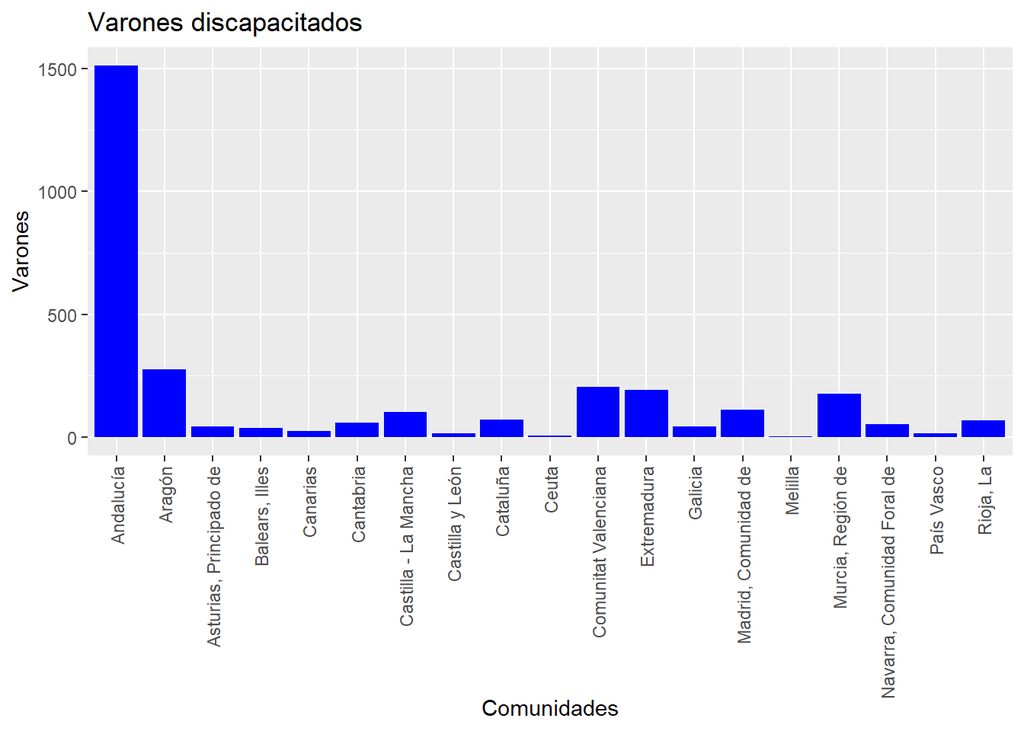

```r
library(tidyverse)

ggplot(data = DiscSexo, aes(x = `Comunidades`, y = `Varones`)) +  geom_bar(stat="identity", position="stack", fill="blue", show.legend = TRUE) + ggtitle("Varones discapacitados") + theme(axis.text.x = element_text(angle = 90, vjust = 0.5, hjust=1))
```

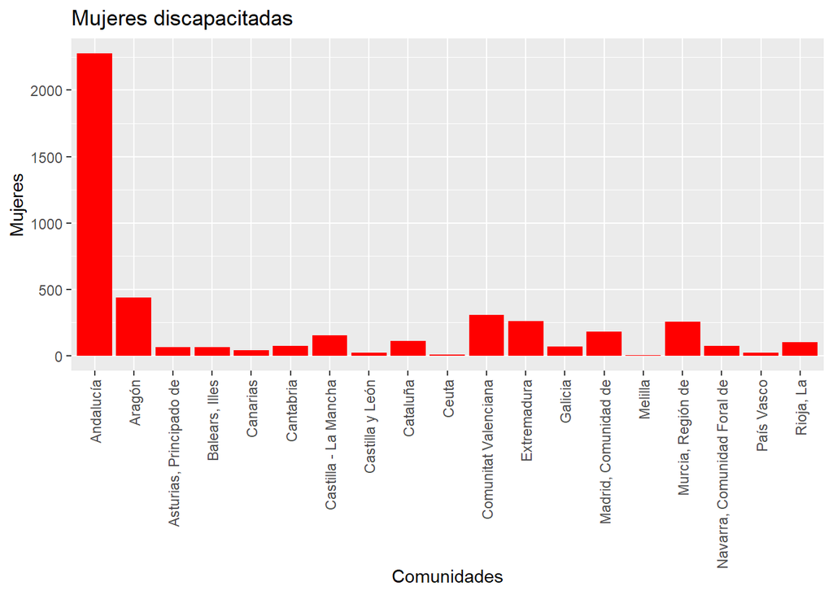

```r
ggplot(data = DiscSexo, aes(x = `Comunidades`, y = `Mujeres`)) +  geom_bar(stat="identity", position="stack", fill="red", show.legend = TRUE) + ggtitle("Mujeres discapacitadas") + theme(axis.text.x = element_text(angle = 90, vjust = 0.5, hjust=1))
```

- **Conclusiones sobre los discapacitados en función del sexo**

Lo primero de todo consideramos importante aclarar que en esta base de datos aparecen el número de personas discapacitadas que hay en cada caso, no son proporciones. Por ello, este set no nos sirve para ver en qué comunidad hay más cantidad de discapacitados, esa característica ya la hemos analizado anteriormente con los datos proporcionales de la cantidad de discapacitados y la densidad demográfica de cada comunidad.

Además también quiero recordar que hemos comprobado que en este caso la mediana y la media no son similares y por ello vamos a sacar conclusiones a partir de la **mediana**, porque **hay datos muy extremos que me distorsionan la media**.

Fijándonos en la mediana vemos hay más cantidad de mujeres discapacitadas que hombres, 75.8 > 60 . Si comparamos los gráficos de barras vemos que esto se aplica a todas las comunidades, y, además estos gráficos tienen la misma tendencia. Para interpretar correctamente esta información tenemos que tener en cuenta que en España durante los últimos años siempre se ha estimado que hay un millón más de mujeres que hombres. Por ejemplo, los datos del año pasado (2020) contabilizan: 24.1 millones de mujeres y 23.2 millones de hombre. Aún teniendo en cuenta esta proporción apreciamos una mayor tendencia a que alguien discapacitado sea mujer.

Para resumir, **en España las causas genéricas que provocan la aparición de una discapacidad afectan más a las mujeres que a los varones**.

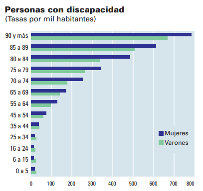

#### ¿Existe alguna relación entre la edad y la discapacidad?

**1.** En primer lugar importamos los datos con “read_excel” porque tienen la extensión “.xsls”.

```r
library(readxl)

DiscEdad <- read_excel("DATA/Discapacidad por edad.xlsx")
```

```
## * `` -> ...1
```

```r
View(DiscEdad)
```

**2.** Vamos a comprobar algunas medidas estadísticas con la información recogidos en las columnas con distintos rangos de edad.

```r
dim(DiscEdad)
```

```
## [1] 19  7
```

```r
class(DiscEdad)
```

```
## [1] "tbl_df"     "tbl"        "data.frame"
```

El set de datos es un tipo de data frame conocido como **tibble**.

Además sabemos que el tibble contiene **19 filas y 7 columnas**, esto es así porque España se compone de 17 comunidades autónomas y 2 cuidades autónomas.

También es conveniente transformar todos los nombres de la columna con “make.names” para cumplan las reglas sintácticas.

```r
make.names(DiscEdad)
```

```
## [1] "c..Andalucía....Aragón....Asturias..Principado.de....Balears..Illes....Canarias....Cantabria....Castilla.y.León....Castilla...La.Mancha....Cataluña....Comunitat.Valenciana....Extremadura....Galicia....Madrid..Comunidad.de....Murcia..Región.de....Navarra..Comunidad.Foral.de....País.Vasco....R…
## [2] "c.608.5..125.1..17.3..13.4..16.4..27.9..5.3..31.6..23.5..74.8..80.6..16.3..38..82.4..22.7..5.1..22..2.2..2.2."
## [3] "c.951.9..200.2..24.1..24.3..18..40.7..9.4..49.8..40.2..137.4..117.5..25.4..64.5..106.6..34.1..8..43.1..4.6..1.6."
## [4] "c.1201.3..233.2..31.6..33.1..17.8..40..9.1..85.9..62.4..165.6..139.7..38.1..95.6..133..41.5..13.2..52.8..4.7..2.1."
## [5] "c.482.6..78.7..19..15.2..6.6..13.6..5.5..40.6..29.5..57.7..57.3..16.1..42.3..47.8..16.3..6.3..26..2.8..0.8."
## [6] "c.339.8..51.8..11.2..11.1..5.8..7.8..5.3..29.9..17.7..47.6..36.8..10.2..32.6..39.7..8.1..5.5..15.5..2..0.6."
## [7] "c.203.4..27.2..8.2..7.4..4.2..5.7..2.9..18.2..9.6..28.6..20.8..4.9..19.9..25.3..4.8..3.4..9.9..1.8..0.2."
```

```r
DiscEdad$`De 6 a 44 años`
```

```
##  [1] 608.5 125.1  17.3  13.4  16.4  27.9   5.3  31.6  23.5  74.8  80.6  16.3
## [13]  38.0  82.4  22.7   5.1  22.0   2.2   2.2
```

```r
is.double(DiscEdad$`De 6 a 44 años`)
```

```
## [1] TRUE
```

```r
typeof(DiscEdad$`De 6 a 44 años`)
```

```
## [1] "double"
```

```r
DiscEdad <- dplyr::rename(.data = DiscEdad, Comunidad =`...1`)

DiscEdad
```

```
## # A tibble: 19 x 7
##    Comunidad `De 6 a 44 años` `De 45 a 64 año~ `De 65 a 79 año~ `De 80 a 84 año~
##    <chr>                <dbl>            <dbl>            <dbl>            <dbl>
##  1 Andalucía            608.             952.            1201.             483.
##  2 Aragón               125.             200.             233.              78.7
##  3 Asturias~             17.3             24.1             31.6             19
##  4 Balears,~             13.4             24.3             33.1             15.2
##  5 Canarias              16.4             18               17.8              6.6
##  6 Cantabria             27.9             40.7             40               13.6
##  7 Castilla~              5.3              9.4              9.1              5.5
##  8 Castilla~             31.6             49.8             85.9             40.6
##  9 Cataluña              23.5             40.2             62.4             29.5
## 10 Comunita~             74.8            137.             166.              57.7
## 11 Extremad~             80.6            118.             140.              57.3
## 12 Galicia               16.3             25.4             38.1             16.1
## 13 Madrid, ~             38               64.5             95.6             42.3
## 14 Murcia, ~             82.4            107.             133               47.8
## 15 Navarra,~             22.7             34.1             41.5             16.3
## 16 País Vas~              5.1              8               13.2              6.3
## 17 Rioja, La             22               43.1             52.8             26
## 18 Ceuta                  2.2              4.6              4.7              2.8
## 19 Melilla                2.2              1.6              2.1              0.8
## # ... with 2 more variables: De 85 a 89 años <dbl>, Más de 90 años <dbl>
```

Los datos de la columnas conlos distintos rangos de edad son “double” así que no será necesario transformarlos.

- **Cálculo conjunto de varias medidas estadísticas (summary)**

Utilizamos la función “summary” para sacar todos los datos estadísticos porque al trabajar con 6 columnas sería muy extenso hacer cada estudio particular.

```r
summary(DiscEdad, na.rm = TRUE)
```

```
##   Comunidad         De 6 a 44 años   De 45 a 64 años  De 65 a 79 años
##  Length:19          Min.   :  2.20   Min.   :  1.60   Min.   :   2.1
##  Class :character   1st Qu.: 14.85   1st Qu.: 21.05   1st Qu.:  24.7
##  Mode  :character   Median : 22.70   Median : 40.20   Median :  41.5
##                     Mean   : 63.96   Mean   :100.07   Mean   : 126.4
##                     3rd Qu.: 56.40   3rd Qu.: 85.55   3rd Qu.: 114.3
##                     Max.   :608.50   Max.   :951.90   Max.   :1201.3
##  De 80 a 84 años  De 85 a 89 años  Más de 90 años
##  Min.   :  0.80   Min.   :  0.60   Min.   :  0.20
##  1st Qu.: 10.10   1st Qu.:  6.80   1st Qu.:  4.50
##  Median : 19.00   Median : 11.20   Median :  8.20
##  Mean   : 50.77   Mean   : 35.74   Mean   : 21.39
##  3rd Qu.: 45.05   3rd Qu.: 34.70   3rd Qu.: 20.35
##  Max.   :482.60   Max.   :339.80   Max.   :203.40
```

El menor mínimo corresponde al grupo de la séptima columna con 0.20.

El mayor máximo corresponde al grupo de la cuarta columna con 1201.3.

En todos las columnas podemos apreciar que la media y la mediana son muy diferentes, lo que refleja que habrá valores extremos en alguna comunidad que distorsionan el significado de la media. Por ello analizaremos la mediana.

Las mayores medianas corresponden a la tercera y cuarto columna con 40.20 y 41.5 respectivamente.

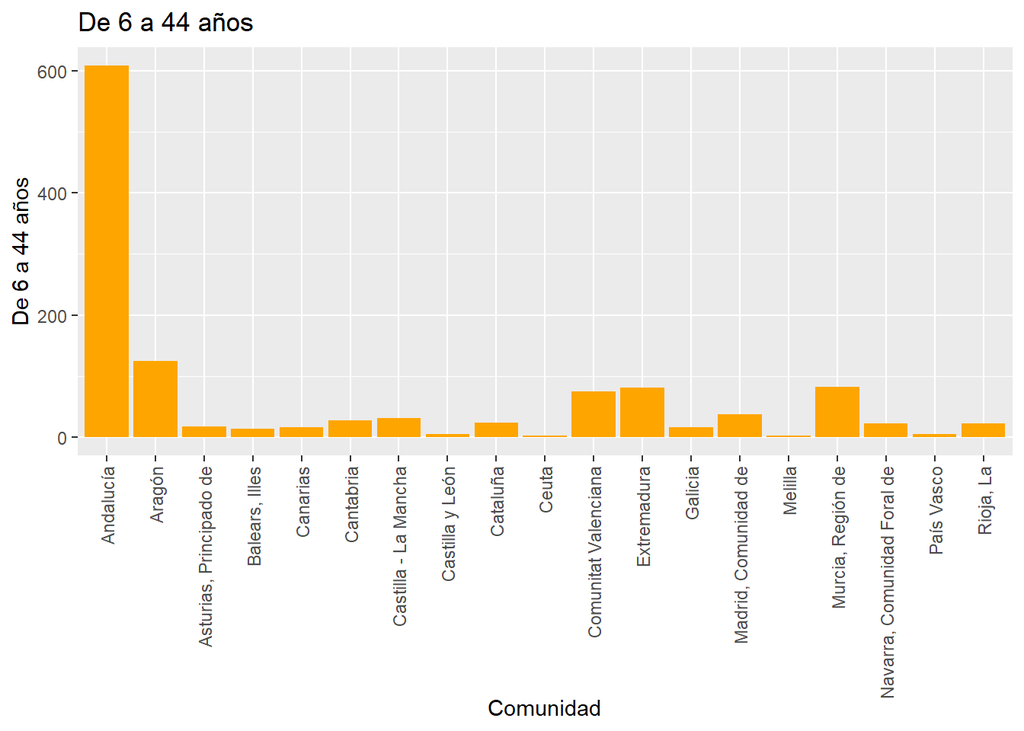

```r
library(tidyverse)

ggplot(data = DiscEdad, aes(x = Comunidad, y = `De 6 a 44 años`)) +  geom_bar(stat="identity", position="stack", fill="orange", show.legend = TRUE) + ggtitle("De 6 a 44 años") + theme(axis.text.x = element_text(angle = 90, vjust = 0.5, hjust=1))
```

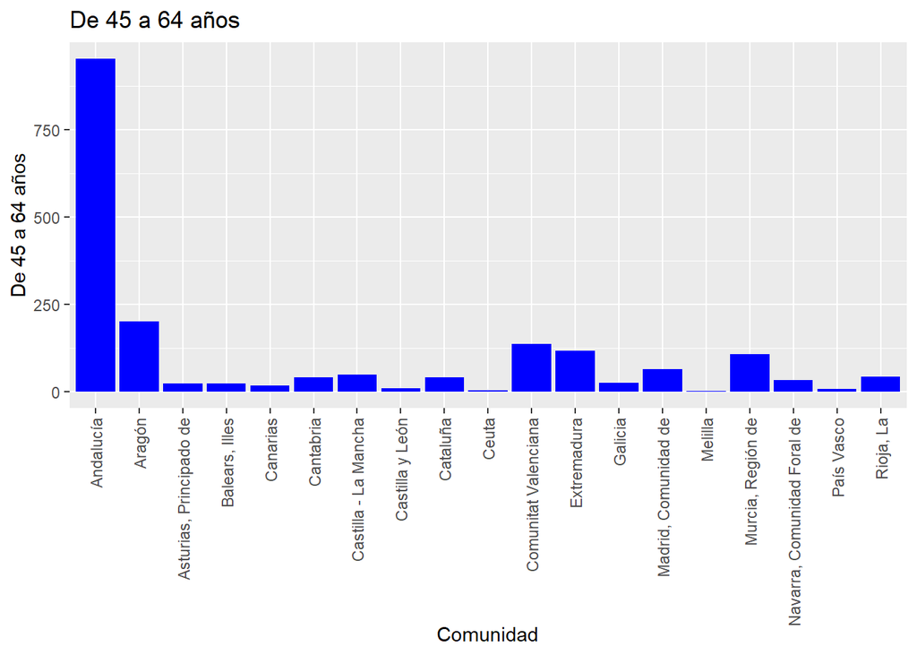

```r
ggplot(data = DiscEdad, aes(x = Comunidad, y = `De 45 a 64 años`)) +  geom_bar(stat="identity", position="stack", fill="blue", show.legend = TRUE) + ggtitle("De 45 a 64 años") + theme(axis.text.x = element_text(angle = 90, vjust = 0.5, hjust=1))
```

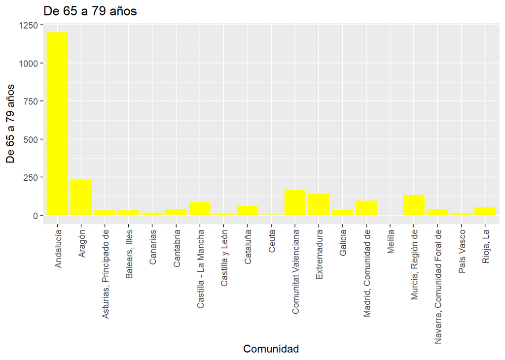

```r
ggplot(data = DiscEdad, aes(x = Comunidad, y = `De 65 a 79 años`)) +  geom_bar(stat="identity", position="stack", fill="yellow", show.legend = TRUE) + ggtitle("De 65 a 79 años") + theme(axis.text.x = element_text(angle = 90, vjust = 0.5, hjust=1))
```

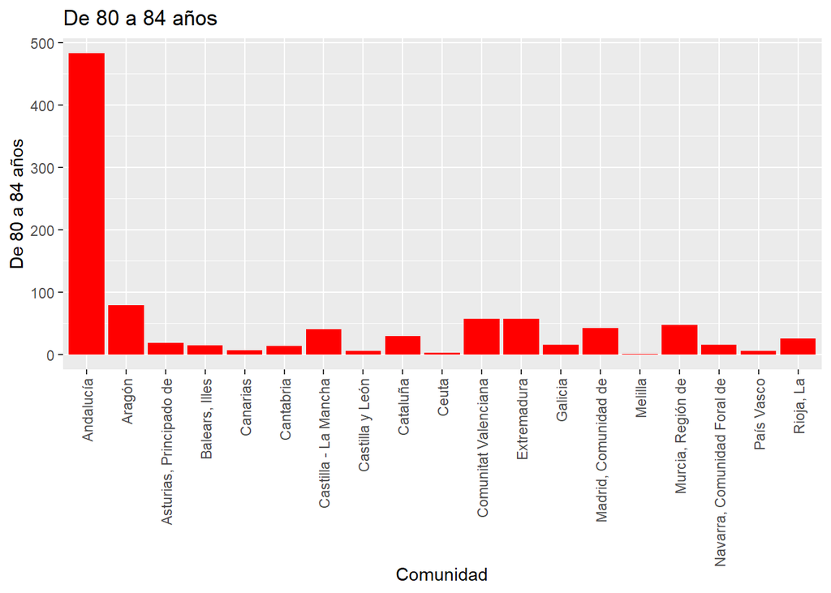

```r
ggplot(data = DiscEdad, aes(x = Comunidad, y = `De 80 a 84 años`)) +  geom_bar(stat="identity", position="stack", fill="red", show.legend = TRUE) + ggtitle("De 80 a 84 años") + theme(axis.text.x = element_text(angle = 90, vjust = 0.5, hjust=1))
```

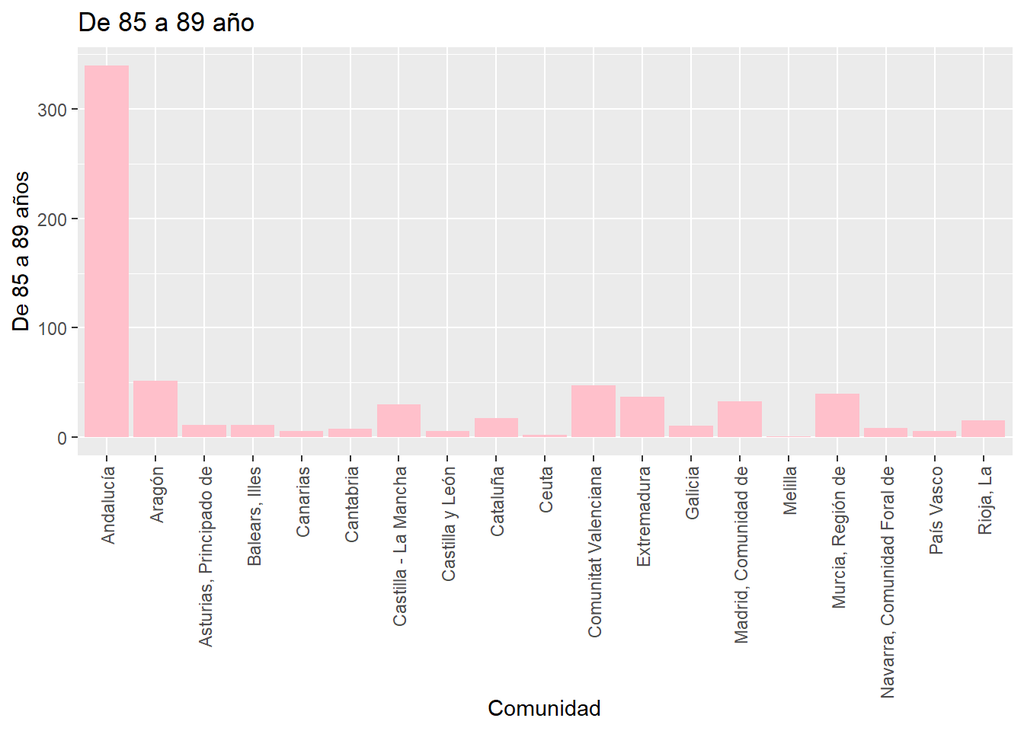

```r
ggplot(data = DiscEdad, aes(x = Comunidad, y = `De 85 a 89 años`)) +  geom_bar(stat="identity", position="stack", fill="pink", show.legend = TRUE) + ggtitle("De 85 a 89 año") + theme(axis.text.x = element_text(angle = 90, vjust = 0.5, hjust=1))
```

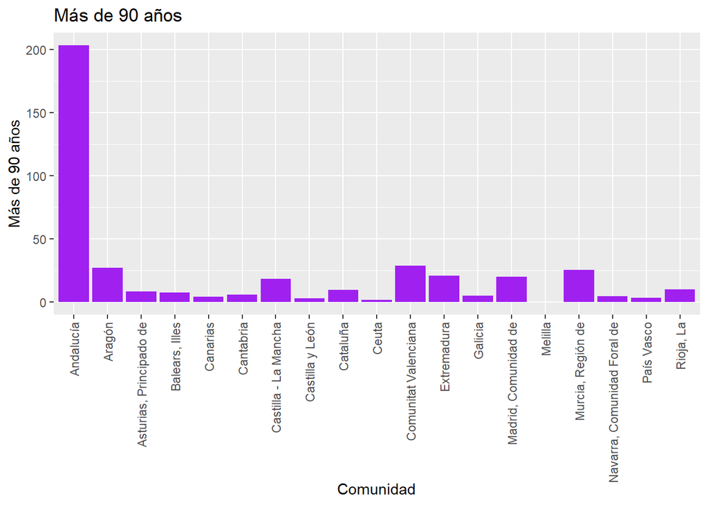

```r
ggplot(data = DiscEdad, aes(x = Comunidad, y = `Más de 90 años`)) +  geom_bar(stat="identity", position="stack", fill="purple", show.legend = TRUE) + ggtitle("Más de 90 años") + theme(axis.text.x = element_text(angle = 90, vjust = 0.5, hjust=1))
```

- **Conclusiones sobre los discapacitados en función de la edad**

Lo primero de todo es necesario aclarar que los datos reflejan la cantidad total de discapacitados por edades en cada comunidad, no trabajan con proporciones en función de la densidad demográfica de cada comunidad. Por eso como Andalucia es la comunidad más poblada aparece como máximo en todos los rangos de edad. También tenemos que tener en cuenta que todos los rangos de edad no representan a la misma cantidad de personas, como sabemos el mayor groso de la población se encuentra entre los 35 y 45 años. Este último aspecto lo tendremos en cuenta para sacar nuestras conclusiones. A continuación apreciamos un gráfico donde se analiza la densidad de la población en función de la edad.

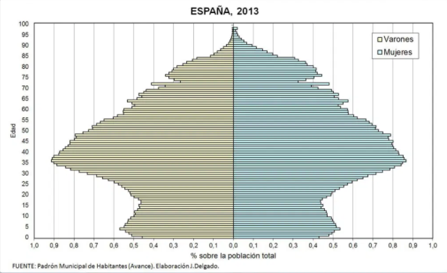

En este caso no nos interesa conocer que ocurre en cada comunidad particularmente, lo que vamos a hacer es sacar conclusiones de los valores medio de cada grupo de edad. Los individuos entre 65 y 79 años reflejan el mayo indice de discapacitados, y además no son el grupo mayoritario en la sociedad. Así que podemos inferir que en estas edades hay mayor proporción de individuos, probablemente se debe al envejecimiento de este sector. Alrededor de esas edades pueden aparecer enfermedades como: cáncer, ictus, parkinson, alzheimer…

Por otro lado, vemos que el grupo de personas entre 45 y 65 años también presentan un alto índice de discapacidos, esto se debe a que son el grupo más abundante y además también existen numerosas enfermedades que afectan a los adultos.

Sorprende ver un índice relativamente alto en el sector más juvenil, y, aunque hay que tener en cuenta que este grupo abarca muchas edades, esto puede reflejar muchas discapacidades se originan por accidentes muy frecuentes en jóvenes. De hecho, en un artículo de divulgación científica se relata lo siguiente: *“De los 3,8 millones de dependientes en España, un total de 86.000 personas presentan alguna discapacidad provocada por accidentes domésticos o de ocio, cifra superior a los discapacitados por causa de accidentes de tráfico, aproximadamente 66.000 personas, según ha concluido un estudio de la Universitat de Barcelona presentado este martes.”*

#### Análisis de los tipos de discapacidad.

**1.** En primer lugar importamos los datos con “read_excel” porque tienen la extensión “.xsls”.

```r
library(readxl)

Discapacidad_y_Autonomia_personal <- read_excel("DATA/Discapacidad y Autonomia personal.xlsx")

View(Discapacidad_y_Autonomia_personal)
```

**2.** Vamos a comprobar algunas medidas estadísticas de las diferentes columnas del set.

```r
dim(Discapacidad_y_Autonomia_personal)
```

```
## [1] 19 14
```

```r
class(Discapacidad_y_Autonomia_personal)
```

```
## [1] "tbl_df"     "tbl"        "data.frame"
```

El set de datos es un tipo de data frame conocido como **tibble**.

Además sabemos que el tibble contiene **19 filas y 14 columnas**, esto es así porque España se compone de 17 comunidades autónomas y 2 cuidades autónomas.

También es conveniente transformar todos los nombres de la columna con “make.names” para cumplan las reglas sintácticas.

```r
make.names(Discapacidad_y_Autonomia_personal)
```

[output not shown]

```r
Discapacidad_y_Autonomia_personal$`Supervivencia a la edad`
```

```
##  [1] 0.7820 0.7412 0.7932 0.7309 0.8366 0.6724 0.6946 0.8354 0.7066 0.7525
## [11] 0.7960 0.8564 0.7431 0.6889 0.7704 0.8341 0.5179 0.4891 0.7927
```

```r
is.double(Discapacidad_y_Autonomia_personal$`Supervivencia a la edad`)
```

```
## [1] TRUE
```

```r
typeof(Discapacidad_y_Autonomia_personal$`Supervivencia a la edad`)
```

```
## [1] "double"
```

- **Análisis estadístico general**

```r
summary(Discapacidad_y_Autonomia_personal, na.rm = TRUE)
```

```
##   Comunidad         Supervivencia a la edad Tasa de enfermedad crónica
##  Length:19          Min.   :0.4891          Min.   :0.4891
##  Class :character   1st Qu.:0.7006          1st Qu.:0.7006
##  Mode  :character   Median :0.7525          Median :0.7525
##                     Mean   :0.7386          Mean   :0.7386
##                     3rd Qu.:0.7946          3rd Qu.:0.7946
##                     Max.   :0.8564          Max.   :0.8564
##  Tasa de mala salud percibida Tasa de discapacidad Tasa de discapacidad severa
##  Min.   :0.0711               Min.   :0.04300      Min.   :0.01940
##  1st Qu.:0.2740               1st Qu.:0.05435      1st Qu.:0.03580
##  Median :0.3049               Median :0.06060      Median :0.04370
##  Mean   :0.3023               Mean   :0.06332      Mean   :0.04435
##  3rd Qu.:0.3534               3rd Qu.:0.06760      3rd Qu.:0.05170
##  Max.   :0.4554               Max.   :0.10310      Max.   :0.06840
##  Tasa de discapacidad de los que necesitan ayudas
##  Min.   :0.02700
##  1st Qu.:0.03470
##  Median :0.03790
##  Mean   :0.04019
##  3rd Qu.:0.04510
##  Max.   :0.06500
##  Tasa de discapacidad para las actividades básicas de la vida diaria
##  Min.   :0.01630
##  1st Qu.:0.03560
##  Median :0.03950
##  Mean   :0.04154
##  3rd Qu.:0.04910
##  Max.   :0.06820
##  Tasa de discapacidad de movilidad Tasa de discapacidad de autocuidado
##  Min.   :0.01810                   Min.   :0.00670
##  1st Qu.:0.03045                   1st Qu.:0.01390
##  Median :0.03890                   Median :0.01790
##  Mean   :0.03841                   Mean   :0.01969
##  3rd Qu.:0.04375                   3rd Qu.:0.02500
##  Max.   :0.07420                   Max.   :0.03490
##  Tasa de discapacidad para realizar las tareas del hogar
##  Min.   :0.01260
##  1st Qu.:0.02460
##  Median :0.03100
##  Mean   :0.02941
##  3rd Qu.:0.03330
##  Max.   :0.04290
##  Tasa de discapacidad de visión Tasa de discapacidad de audición
##  Min.   :0.00540                Min.   :0.00290
##  1st Qu.:0.00915                1st Qu.:0.00740
##  Median :0.01060                Median :0.00980
##  Mean   :0.01224                Mean   :0.01119
##  3rd Qu.:0.01510                3rd Qu.:0.01460
##  Max.   :0.02420                Max.   :0.02290
##  Tasa de discapacidad de deficiencias osteoarticulares
##  Min.   :0.00440
##  1st Qu.:0.01365
##  Median :0.02110
##  Mean   :0.02185
##  3rd Qu.:0.02640
##  Max.   :0.06120
```

- **Análisis estadístico por columna**

```r
summary(Discapacidad_y_Autonomia_personal$`Supervivencia a la edad`, na.rm = TRUE)
```

```
##    Min. 1st Qu.  Median    Mean 3rd Qu.    Max.
##  0.4891  0.7006  0.7525  0.7386  0.7946  0.8564
```

```r
Discapacidad_y_Autonomia_personal$`Comunidad`[Discapacidad_y_Autonomia_personal$`Supervivencia a la edad` == min(Discapacidad_y_Autonomia_personal$`Supervivencia a la edad`, na.rm = TRUE)]
```

```
## [1] "Ceuta"
```

```r
Discapacidad_y_Autonomia_personal$`Comunidad`[Discapacidad_y_Autonomia_personal$`Supervivencia a la edad` == max(Discapacidad_y_Autonomia_personal$`Supervivencia a la edad`, na.rm = TRUE)]
```

```
## [1] "Galicia"
```

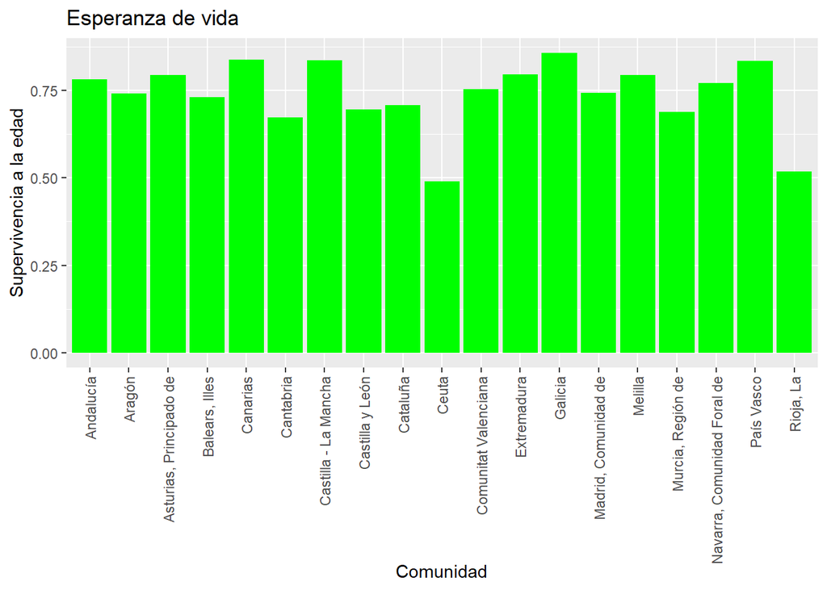

```r
library(tidyverse)
ggplot(data = Discapacidad_y_Autonomia_personal, aes(x = `Comunidad`, y = `Supervivencia a la edad`)) +  geom_bar(stat="identity", position="stack", fill="green") + ggtitle("Esperanza de vida") + theme(axis.text.x = element_text(angle = 90, vjust = 0.5, hjust=1))
```

[figure not shown]

```r
summary(Discapacidad_y_Autonomia_personal$`Tasa de enfermedad crónica`, na.rm = TRUE)
```

```
##    Min. 1st Qu.  Median    Mean 3rd Qu.    Max.
##  0.4891  0.7006  0.7525  0.7386  0.7946  0.8564
```

```r
Discapacidad_y_Autonomia_personal$`Comunidad`[Discapacidad_y_Autonomia_personal$`Tasa de enfermedad crónica` == min(Discapacidad_y_Autonomia_personal$`Tasa de enfermedad crónica`, na.rm = TRUE)]
```

```
## [1] "Ceuta"
```

```r
Discapacidad_y_Autonomia_personal$`Comunidad`[Discapacidad_y_Autonomia_personal$`Tasa de enfermedad crónica` == max(Discapacidad_y_Autonomia_personal$`Tasa de enfermedad crónica`, na.rm = TRUE)]
```

```
## [1] "Galicia"
```

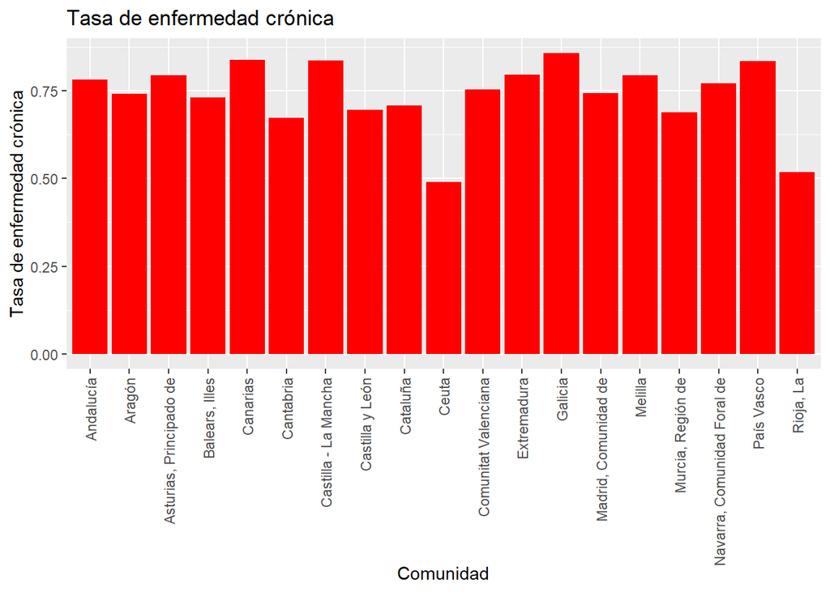

```r
library(tidyverse)
ggplot(data = Discapacidad_y_Autonomia_personal, aes(x = `Comunidad`, y = `Tasa de enfermedad crónica`)) +  geom_bar(stat="identity", position="stack", fill="red") + ggtitle("Tasa de enfermedad crónica") + theme(axis.text.x = element_text(angle = 90, vjust = 0.5, hjust=1))
```

Con respecto a la proporción de enfermedades crónicas, vemos que, de nuevo, los habitantes de Galicia son los que más enfermedades crónicas, mientras que los Ceuta tienen la menor proporción.

```r
summary(Discapacidad_y_Autonomia_personal$`Tasa de mala salud percibida`, na.rm = TRUE)
```

```
##    Min. 1st Qu.  Median    Mean 3rd Qu.    Max.
##  0.0711  0.2740  0.3049  0.3023  0.3534  0.4554
```

```r
Discapacidad_y_Autonomia_personal$`Comunidad`[Discapacidad_y_Autonomia_personal$`Tasa de mala salud percibida` == min(Discapacidad_y_Autonomia_personal$`Tasa de mala salud percibida`, na.rm = TRUE)]
```

```
## [1] "Ceuta"
```

```r
Discapacidad_y_Autonomia_personal$`Comunidad`[Discapacidad_y_Autonomia_personal$`Tasa de mala salud percibida` == max(Discapacidad_y_Autonomia_personal$`Tasa de mala salud percibida`, na.rm = TRUE)]
```

```
## [1] "Melilla"
```

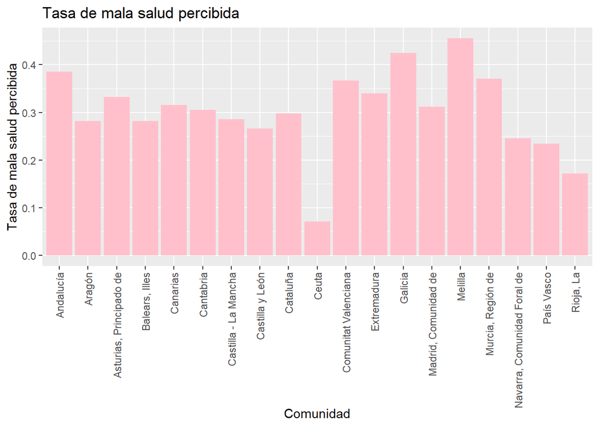

```r
library(tidyverse)
ggplot(data = Discapacidad_y_Autonomia_personal, aes(x = `Comunidad`, y = `Tasa de mala salud percibida`)) +  geom_bar(stat="identity", position="stack", fill="pink") + ggtitle("Tasa de mala salud percibida") + theme(axis.text.x = element_text(angle = 90, vjust = 0.5, hjust=1))
```

Con respectoa la tasa de mala salud percibida, Ceuta es la región con mejor salud y Melilla la que peor tasa de salud presenta. Al ser ciudades autónomas pequeñas no son muy significativas así que vamos a fijarnos en las comunidades que habíamos establecido como más significativas. Por un lado, en cuanto al ámbito rural, Castilla y León presenta níveles medios. Y, por otro lado, del ámbito urbano, Madrid tiene una tasa algo superior a la media, pero sin diferencias esclarecedoras. Así que **no parece que la salud sea mejor en ámbitos rurales**, aunque aún nos falta responder a: ¿la atención sanitaria es igual de satisfactorio en pueblos que en ciudades?

```r
summary(Discapacidad_y_Autonomia_personal$`Tasa de discapacidad`, na.rm = TRUE)
```

```
##    Min. 1st Qu.  Median    Mean 3rd Qu.    Max.
## 0.04300 0.05435 0.06060 0.06332 0.06760 0.10310
```

```r
Discapacidad_y_Autonomia_personal$`Comunidad`[Discapacidad_y_Autonomia_personal$`Tasa de discapacidad` == min(Discapacidad_y_Autonomia_personal$`Tasa de discapacidad`, na.rm = TRUE)]
```

```
## [1] "Navarra, Comunidad Foral de"
```

```r
Discapacidad_y_Autonomia_personal$`Comunidad`[Discapacidad_y_Autonomia_personal$`Tasa de discapacidad` == max(Discapacidad_y_Autonomia_personal$`Tasa de discapacidad`, na.rm = TRUE)]
```

```
## [1] "Melilla"
```

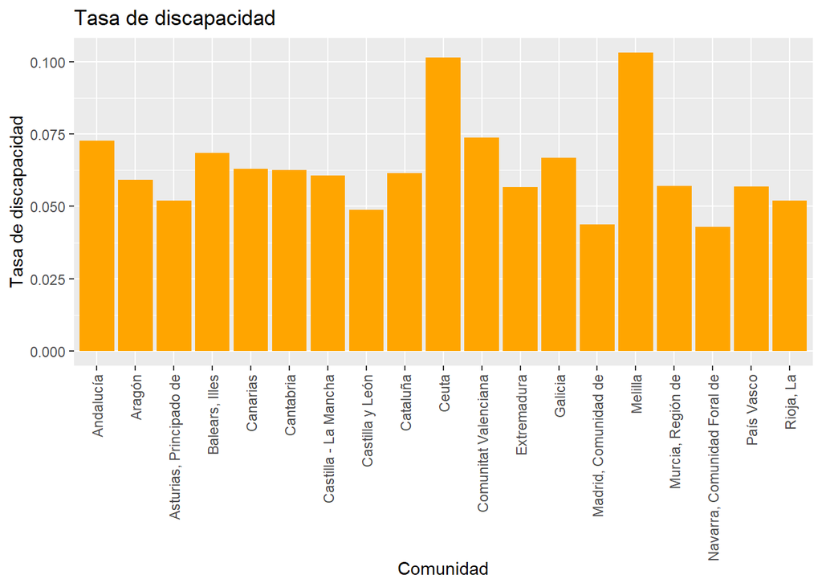

```r
library(tidyverse)
ggplot(data = Discapacidad_y_Autonomia_personal, aes(x = `Comunidad`, y = `Tasa de discapacidad`)) +  geom_bar(stat="identity", position="stack", fill="orange") + ggtitle("Tasa de discapacidad") + theme(axis.text.x = element_text(angle = 90, vjust = 0.5, hjust=1))
```

```r
Discapacitados %>%
  full_join(x = ., y = Discapacidad_y_Autonomia_personal %>%
              select(`Comunidad`, `Tasa de discapacidad`),
            by = c("Comunidades" = "Comunidad"))
```

```
## # A tibble: 19 x 3
##    Comunidades                 `Personas con discapacidad` `Tasa de discapacida~
##    <chr>                                             <dbl>                 <dbl>
##  1 Andalucía                                          16.7                0.0728
##  2 Aragón                                             19.8                0.0591
##  3 Asturias, Principado de                            12.6                0.052
##  4 Balears, Illes                                     19.1                0.0685
##  5 Canarias                                           12.9                0.063
##  6 Cantabria                                          17.6                0.0626
##  7 Castilla y León                                    16.0                0.0488
##  8 Castilla - La Mancha                               13.7                0.0606
##  9 Cataluña                                           16.9                0.0615
## 10 Comunitat Valenciana                               16.2                0.0737
## 11 Extremadura                                        17.7                0.0567
## 12 Galicia                                            17.2                0.0667
## 13 Madrid, Comunidad de                               17.6                0.0438
## 14 Murcia, Región de                                  13.6                0.057
## 15 Navarra, Comunidad Foral de                        19.6                0.043
## 16 País Vasco                                         13.6                0.0568
## 17 Rioja, La                                          17.2                0.0519
## 18 Ceuta                                              17.2                0.102
## 19 Melilla                                            16.2                0.103
```

```r
summary(Discapacidad_y_Autonomia_personal$`Tasa de discapacidad severa`, na.rm = TRUE)
```

```
##    Min. 1st Qu.  Median    Mean 3rd Qu.    Max.
## 0.01940 0.03580 0.04370 0.04435 0.05170 0.06840
```

```r
Discapacidad_y_Autonomia_personal$`Comunidad`[Discapacidad_y_Autonomia_personal$`Tasa de discapacidad severa` == min(Discapacidad_y_Autonomia_personal$`Tasa de discapacidad severa`, na.rm = TRUE)]
```

```
## [1] "Madrid, Comunidad de"
```

```r
Discapacidad_y_Autonomia_personal$`Comunidad`[Discapacidad_y_Autonomia_personal$`Tasa de discapacidad severa` == max(Discapacidad_y_Autonomia_personal$`Tasa de discapacidad severa`, na.rm = TRUE)]
```

```
## [1] "Melilla"
```

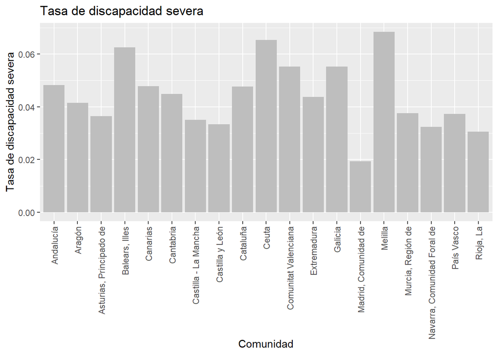

```r
library(tidyverse)
ggplot(data = Discapacidad_y_Autonomia_personal, aes(x = `Comunidad`, y = `Tasa de discapacidad severa`)) +  geom_bar(stat="identity", position="stack", fill="grey") + ggtitle("Tasa de discapacidad severa") + theme(axis.text.x = element_text(angle = 90, vjust = 0.5, hjust=1))
```

Con respecto a la tasa de discapacidad severa, Madrid presenta el menor índice, mientras que Melilla tiene la mayor tasa de discapacitados severos.

```r
summary(Discapacidad_y_Autonomia_personal$`Tasa de discapacidad de los que necesitan ayudas`, na.rm = TRUE)
```

```
##    Min. 1st Qu.  Median    Mean 3rd Qu.    Max.
## 0.02700 0.03470 0.03790 0.04019 0.04510 0.06500
```

```r
Discapacidad_y_Autonomia_personal$`Comunidad`[Discapacidad_y_Autonomia_personal$`Tasa de discapacidad de los que necesitan ayudas` == min(Discapacidad_y_Autonomia_personal$`Tasa de discapacidad de los que necesitan ayudas`, na.rm = TRUE)]
```

```
## [1] "Madrid, Comunidad de"
```

```r
Discapacidad_y_Autonomia_personal$`Comunidad`[Discapacidad_y_Autonomia_personal$`Tasa de discapacidad de los que necesitan ayudas` == max(Discapacidad_y_Autonomia_personal$`Tasa de discapacidad de los que necesitan ayudas`, na.rm = TRUE)]
```

```
## [1] "Ceuta"
```

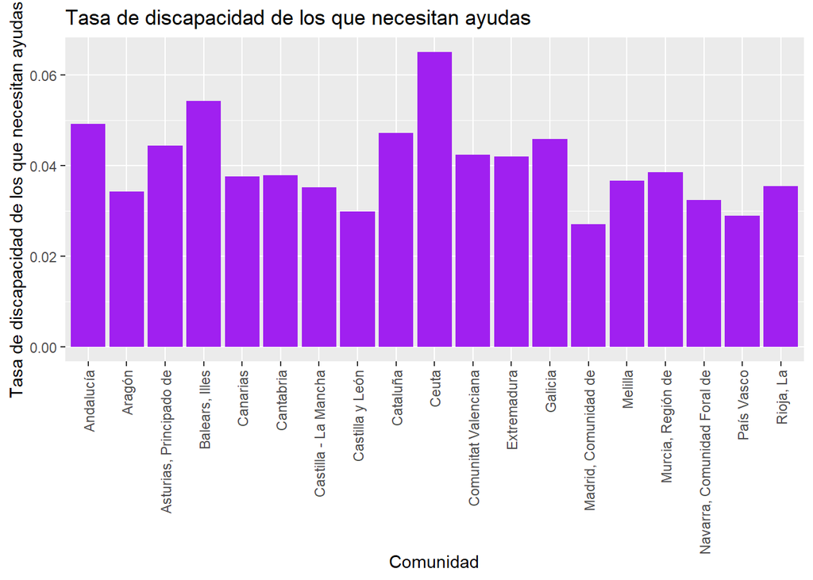

```r
library(tidyverse)
ggplot(data = Discapacidad_y_Autonomia_personal, aes(x = `Comunidad`, y = `Tasa de discapacidad de los que necesitan ayudas`)) +  geom_bar(stat="identity", position="stack", fill="purple") + ggtitle("Tasa de discapacidad de los que necesitan ayudas") + theme(axis.text.x = element_text(angle = 90, vjust = 0.5, hjust=1))
```

Con respecto a tasa de discapacidad de los que necesitan ayudas, Madrid presenta el menor índice, mientras que Ceuta tiene la mayor tasa de discapacitados severos. Son resultados muy similares a los de la tasa de discapacidad severa, dado que es lógico que las personas con minusvalías más graves necesiten más ayuda. Podemos comparar mejor los valores de ambas columnas seleccionandolas.

```r
Discapacidad_y_Autonomia_personal %>%
  select(`Comunidad`, `Tasa de discapacidad severa`, `Tasa de discapacidad de los que necesitan ayudas`)
```

```
## # A tibble: 19 x 3
##    Comunidad                   `Tasa de discapacidad severa` `Tasa de discapaci~
##    <chr>                                               <dbl>               <dbl>
##  1 Andalucía                                          0.0482              0.0491
##  2 Aragón                                             0.0415              0.0342
##  3 Asturias, Principado de                            0.0365              0.0444
##  4 Balears, Illes                                     0.0625              0.0542
##  5 Canarias                                           0.0478              0.0376
##  6 Cantabria                                          0.0449              0.0379
##  7 Castilla y León                                    0.0333              0.0298
##  8 Castilla - La Mancha                               0.0351              0.0352
##  9 Cataluña                                           0.0477              0.0472
## 10 Comunitat Valenciana                               0.0553              0.0424
## 11 Extremadura                                        0.0437              0.042
## 12 Galicia                                            0.0552              0.0458
## 13 Madrid, Comunidad de                               0.0194              0.027
## 14 Murcia, Región de                                  0.0376              0.0385
## 15 Navarra, Comunidad Foral de                        0.0324              0.0324
## 16 País Vasco                                         0.0373              0.0289
## 17 Rioja, La                                          0.0305              0.0355
## 18 Ceuta                                              0.0654              0.065
## 19 Melilla                                            0.0684              0.0366
```

```r
summary(Discapacidad_y_Autonomia_personal$`Tasa de discapacidad para las actividades básicas de la vida diaria`, na.rm = TRUE)
```

```
##    Min. 1st Qu.  Median    Mean 3rd Qu.    Max.
## 0.01630 0.03560 0.03950 0.04154 0.04910 0.06820
```

```r
Discapacidad_y_Autonomia_personal$`Comunidad`[Discapacidad_y_Autonomia_personal$`Tasa de discapacidad para las actividades básicas de la vida diaria` == min(Discapacidad_y_Autonomia_personal$`Tasa de discapacidad para las actividades básicas de la vida diaria`, na.rm = TRUE)]
```

```
## [1] "Navarra, Comunidad Foral de"
```

```r
Discapacidad_y_Autonomia_personal$`Comunidad`[Discapacidad_y_Autonomia_personal$`Tasa de discapacidad para las actividades básicas de la vida diaria` == max(Discapacidad_y_Autonomia_personal$`Tasa de discapacidad para las actividades básicas de la vida diaria`, na.rm = TRUE)]
```

```
## [1] "Ceuta"
```

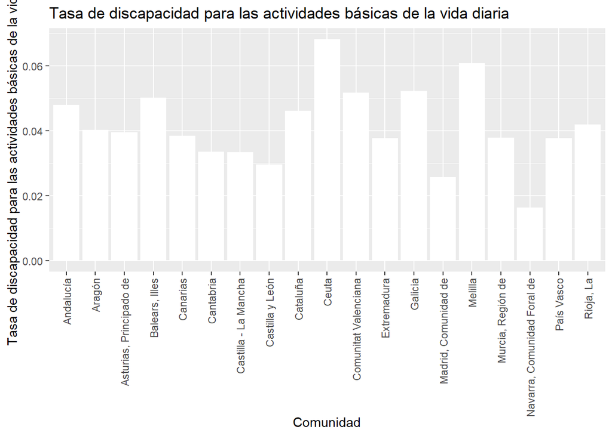

```r
library(tidyverse)
ggplot(data = Discapacidad_y_Autonomia_personal, aes(x = `Comunidad`, y = `Tasa de discapacidad para las actividades básicas de la vida diaria`)) +  geom_bar(stat="identity", position="stack", fill="white") + ggtitle("Tasa de discapacidad para las actividades básicas de la vida diaria") + theme(axis.text.x = element_text(angle = 90, vjust = 0.5, hjust=1))
```

Con respecto a tasa de discapacidad para las actividades básicas de la vida diaria, Navarra presenta el menor índice, mientras que Ceuta tiene la mayor tasa de discapacitados. Luego analizaremos mejor qué actividades pueden verse afectadas ante una discapacidad.

```r
summary(Discapacidad_y_Autonomia_personal$`Tasa de discapacidad de movilidad`, na.rm = TRUE)
```

```
##    Min. 1st Qu.  Median    Mean 3rd Qu.    Max.
## 0.01810 0.03045 0.03890 0.03841 0.04375 0.07420
```

```r
Discapacidad_y_Autonomia_personal$`Comunidad`[Discapacidad_y_Autonomia_personal$`Tasa de discapacidad de movilidad` == min(Discapacidad_y_Autonomia_personal$`Tasa de discapacidad de movilidad`, na.rm = TRUE)]
```

```
## [1] "Navarra, Comunidad Foral de"
```

```r
Discapacidad_y_Autonomia_personal$`Comunidad`[Discapacidad_y_Autonomia_personal$`Tasa de discapacidad de movilidad` == max(Discapacidad_y_Autonomia_personal$`Tasa de discapacidad de movilidad`, na.rm = TRUE)]
```

```
## [1] "Melilla"
```

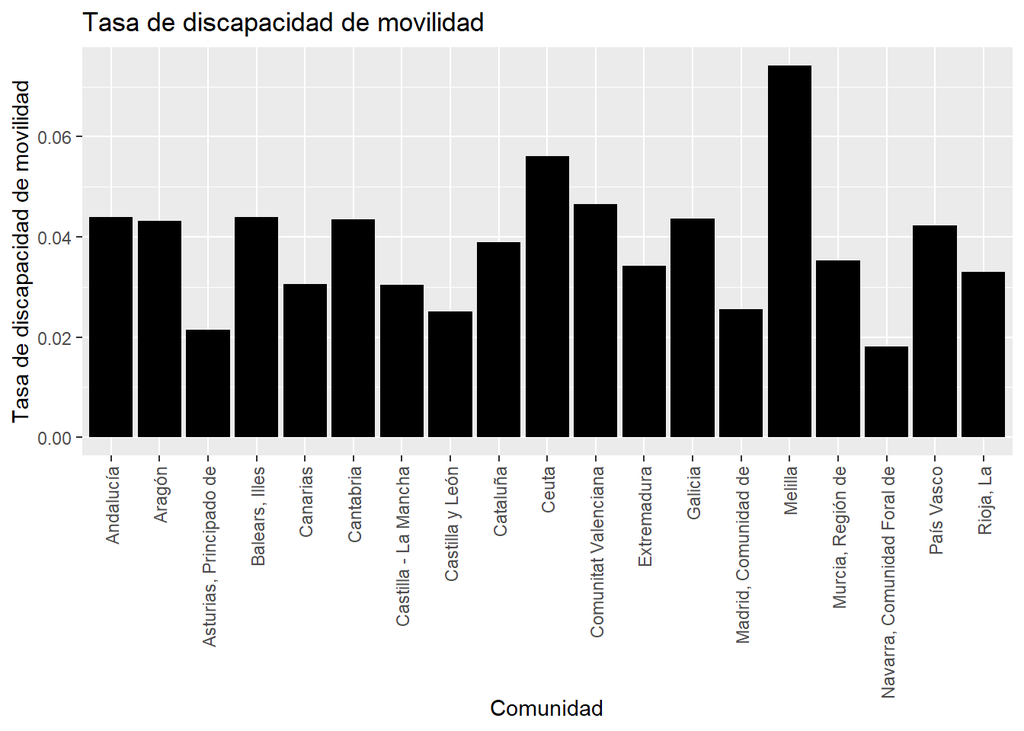

```r
library(tidyverse)
ggplot(data = Discapacidad_y_Autonomia_personal, aes(x = `Comunidad`, y = `Tasa de discapacidad de movilidad`)) +  geom_bar(stat="identity", position="stack", fill="black") + ggtitle("Tasa de discapacidad de movilidad") + theme(axis.text.x = element_text(angle = 90, vjust = 0.5, hjust=1))
```

```r
summary(Discapacidad_y_Autonomia_personal$`Tasa de discapacidad de autocuidado`, na.rm = TRUE)
```

```
##    Min. 1st Qu.  Median    Mean 3rd Qu.    Max.
## 0.00670 0.01390 0.01790 0.01969 0.02500 0.03490
```

```r
Discapacidad_y_Autonomia_personal$`Comunidad`[Discapacidad_y_Autonomia_personal$`Tasa de discapacidad de autocuidado` == min(Discapacidad_y_Autonomia_personal$`Tasa de discapacidad de autocuidado`, na.rm = TRUE)]
```

```
## [1] "Navarra, Comunidad Foral de"
```

```r
Discapacidad_y_Autonomia_personal$`Comunidad`[Discapacidad_y_Autonomia_personal$`Tasa de discapacidad de autocuidado` == max(Discapacidad_y_Autonomia_personal$`Tasa de discapacidad de autocuidado`, na.rm = TRUE)]
```

```
## [1] "Galicia"
```

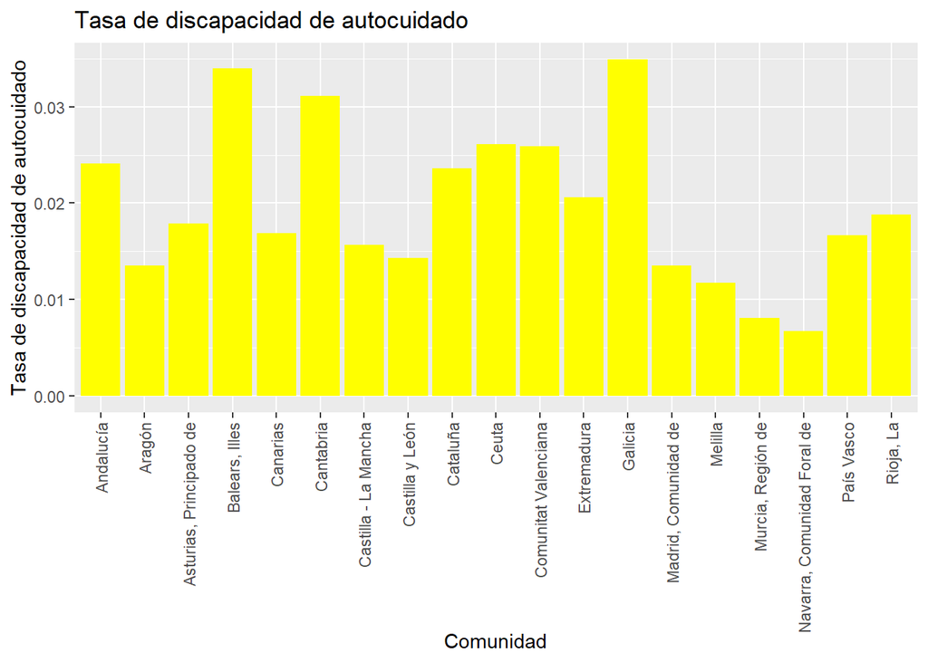

```r
library(tidyverse)
ggplot(data = Discapacidad_y_Autonomia_personal, aes(x = `Comunidad`, y = `Tasa de discapacidad de autocuidado`)) +  geom_bar(stat="identity", position="stack", fill="yellow") + ggtitle("Tasa de discapacidad de autocuidado") + theme(axis.text.x = element_text(angle = 90, vjust = 0.5, hjust=1))
```

Con respecto a la discapacidad de autocuidado, Navarra presenta los valores más bajos, mientras que Galicia tiene la mayor tasa.

```r
summary(Discapacidad_y_Autonomia_personal$`Tasa de discapacidad para realizar las tareas del hogar`, na.rm = TRUE)
```

```
##    Min. 1st Qu.  Median    Mean 3rd Qu.    Max.
## 0.01260 0.02460 0.03100 0.02941 0.03330 0.04290
```

```r
Discapacidad_y_Autonomia_personal$`Comunidad`[Discapacidad_y_Autonomia_personal$`Tasa de discapacidad para realizar las tareas del hogar` == min(Discapacidad_y_Autonomia_personal$`Tasa de discapacidad para realizar las tareas del hogar`, na.rm = TRUE)]
```

```
## [1] "Navarra, Comunidad Foral de"
```

```r
Discapacidad_y_Autonomia_personal$`Comunidad`[Discapacidad_y_Autonomia_personal$`Tasa de discapacidad para realizar las tareas del hogar` == max(Discapacidad_y_Autonomia_personal$`Tasa de discapacidad para realizar las tareas del hogar`, na.rm = TRUE)]
```

```
## [1] "Melilla"
```

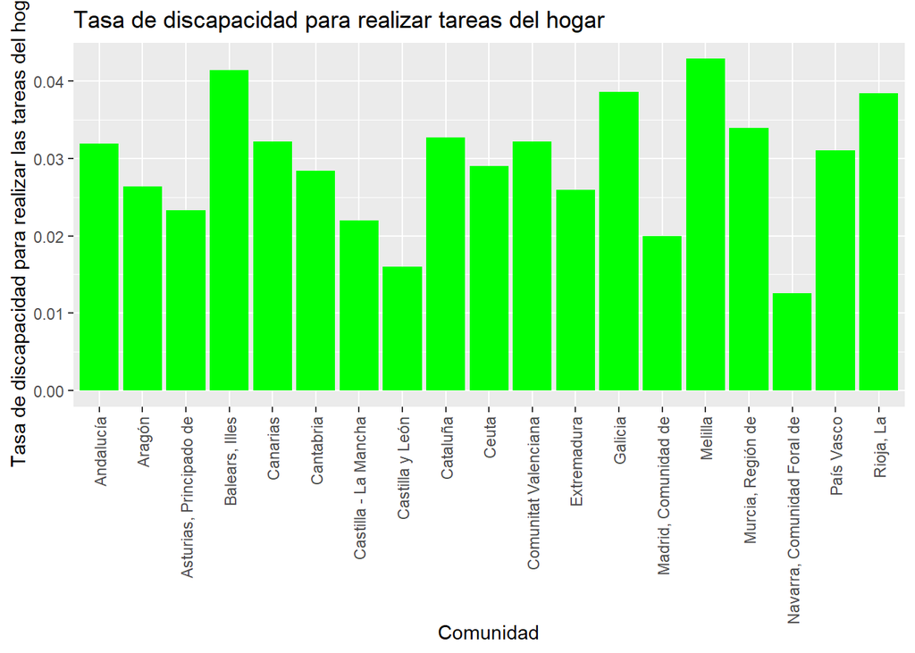

```r
library(tidyverse)
ggplot(data = Discapacidad_y_Autonomia_personal, aes(x = `Comunidad`, y = `Tasa de discapacidad para realizar las tareas del hogar`)) +  geom_bar(stat="identity", position="stack", fill="green") + ggtitle("Tasa de discapacidad para realizar tareas del hogar") + theme(axis.text.x = element_text(angle = 90, vjust = 0.5, hjust=1))
```

Con respecto a la discapacidad para realizar las tareas del hogar, de nuevo vemos que Navarra presenta los valores más bajos, mientras que Melilla tiene la mayor tasa.

```r
summary(Discapacidad_y_Autonomia_personal$`Tasa de discapacidad de visión`, na.rm = TRUE)
```

```
##    Min. 1st Qu.  Median    Mean 3rd Qu.    Max.
## 0.00540 0.00915 0.01060 0.01224 0.01510 0.02420
```

```r
Discapacidad_y_Autonomia_personal$`Comunidad`[Discapacidad_y_Autonomia_personal$`Tasa de discapacidad de visión` == min(Discapacidad_y_Autonomia_personal$`Tasa de discapacidad de visión`, na.rm = TRUE)]
```

```
## [1] "Extremadura"
```

```r
Discapacidad_y_Autonomia_personal$`Comunidad`[Discapacidad_y_Autonomia_personal$`Tasa de discapacidad de visión` == max(Discapacidad_y_Autonomia_personal$`Tasa de discapacidad de visión`, na.rm = TRUE)]
```

```
## [1] "Melilla"
```

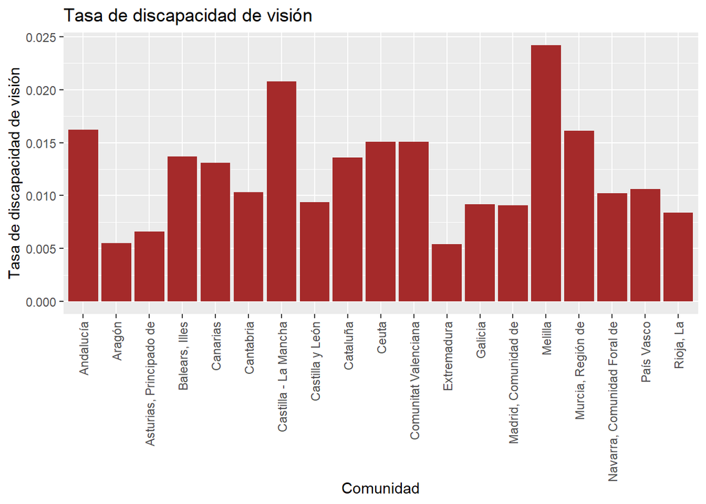

```r
library(tidyverse)
ggplot(data = Discapacidad_y_Autonomia_personal, aes(x = `Comunidad`, y = `Tasa de discapacidad de visión`)) +  geom_bar(stat="identity", position="stack", fill="brown") + ggtitle("Tasa de discapacidad de visión") + theme(axis.text.x = element_text(angle = 90, vjust = 0.5, hjust=1))
```

Con respecto a la discapacidad de visión vemos que Extremadura presenta los valores más bajos, mientras que Melilla tiene la mayor tasa.

```r
summary(Discapacidad_y_Autonomia_personal$`Tasa de discapacidad de audición`, na.rm = TRUE)
```

```
##    Min. 1st Qu.  Median    Mean 3rd Qu.    Max.
## 0.00290 0.00740 0.00980 0.01119 0.01460 0.02290
```

```r
Discapacidad_y_Autonomia_personal$`Comunidad`[Discapacidad_y_Autonomia_personal$`Tasa de discapacidad de audición` == min(Discapacidad_y_Autonomia_personal$`Tasa de discapacidad de audición`, na.rm = TRUE)]
```

```
## [1] "Balears, Illes"
```

```r
Discapacidad_y_Autonomia_personal$`Comunidad`[Discapacidad_y_Autonomia_personal$`Tasa de discapacidad de audición` == max(Discapacidad_y_Autonomia_personal$`Tasa de discapacidad de audición`, na.rm = TRUE)]
```

```
## [1] "Ceuta"
```

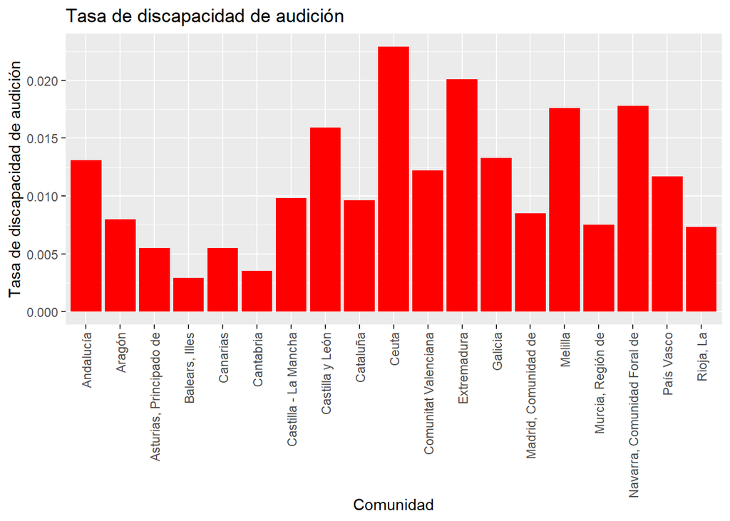

```r
library(tidyverse)
ggplot(data = Discapacidad_y_Autonomia_personal, aes(x = `Comunidad`, y = `Tasa de discapacidad de audición`)) +  geom_bar(stat="identity", position="stack", fill="red") + ggtitle("Tasa de discapacidad de audición") + theme(axis.text.x = element_text(angle = 90, vjust = 0.5, hjust=1))
```

Con respecto a la discapacidad de audición vemos que las Islas Baleares presenta los valores más bajos, mientras que Ceuta tiene la mayor tasa.

```r
summary(Discapacidad_y_Autonomia_personal$`Tasa de discapacidad de deficiencias osteoarticulares`, na.rm = TRUE)
```

```
##    Min. 1st Qu.  Median    Mean 3rd Qu.    Max.
## 0.00440 0.01365 0.02110 0.02185 0.02640 0.06120
```

```r
Discapacidad_y_Autonomia_personal$`Comunidad`[Discapacidad_y_Autonomia_personal$`Tasa de discapacidad de deficiencias osteoarticulares` == min(Discapacidad_y_Autonomia_personal$`Tasa de discapacidad de deficiencias osteoarticulares`, na.rm = TRUE)]
```

```
## [1] "Ceuta"
```

```r
Discapacidad_y_Autonomia_personal$`Comunidad`[Discapacidad_y_Autonomia_personal$`Tasa de discapacidad de deficiencias osteoarticulares` == max(Discapacidad_y_Autonomia_personal$`Tasa de discapacidad de deficiencias osteoarticulares`, na.rm = TRUE)]
```

```
## [1] "Melilla"
```

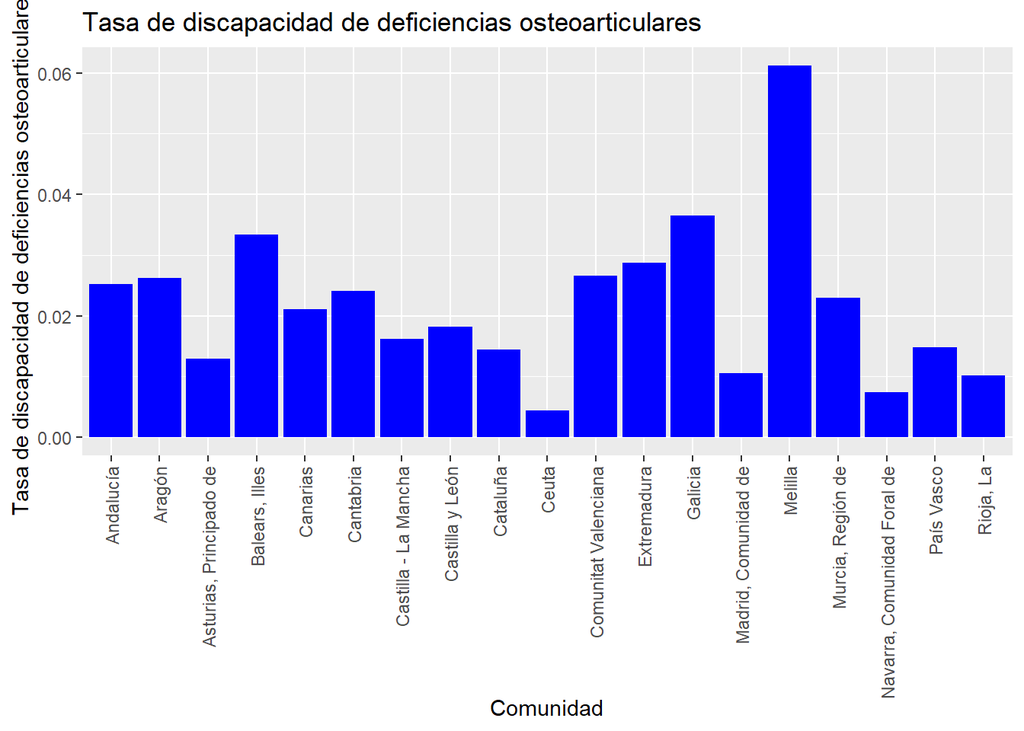

```r
library(tidyverse)
ggplot(data = Discapacidad_y_Autonomia_personal, aes(x = `Comunidad`, y = `Tasa de discapacidad de deficiencias osteoarticulares`)) +  geom_bar(stat="identity", position="stack", fill="blue") + ggtitle("Tasa de discapacidad de deficiencias osteoarticulares") + theme(axis.text.x = element_text(angle = 90, vjust = 0.5, hjust=1))
```

Con respecto a la discapacidad de deficiencias osteoarticulares vemos que las Ceuta presenta los valores más bajos, mientras que Melilla tiene la mayor tasa.

- **Conclusiones sobre la discapacidades y la autonomía personal**

De forma muy resumida diremos que Navarra muestra, para muchos de los atributos, la tasa más baja de discapacitados. Este dato resulta interesante porque, cuando hemos analizado la proporción de discapacidatos por comunidad, Navarra no tenían la proporción más baja. Por lógica podríamos pensar que entonces **Navarra** tendrá una gran calidad en su servicio sanitario y, por tanto, los individuos dispacitados presentan bastante autonomía personal, pero es algo que verificaremos más adelante. Además cabe añadir que para ningún atributo se ha apreciado un gran diferencia entre las comunidades urbanas y rurales.